# eM Pe De We

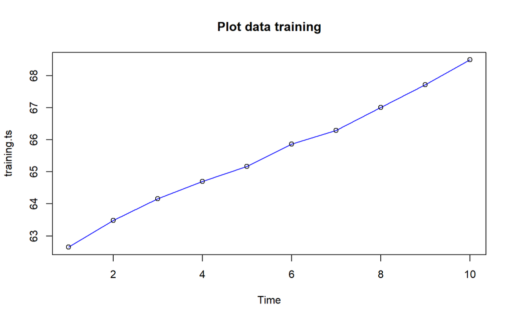

```r
plot(training.ts, col="blue",main="Plot data training")
points(training.ts)
```

Selanjutnya akan dilakukan pemulusan dengan DES, kali ini langsung dicari lambda dan gamma optimum sebagai berikut. Nilai lambda dan gamma optimum dapat dilihat pada smoothing parameters alpha untuk nilai lambda dan beta untuk nilai gamma.

```r
#Lamda dan gamma optimum
des.opt<- HoltWinters(training.ts, gamma = FALSE)
des.opt
```

```
## Holt-Winters exponential smoothing with trend and without seasonal component.
##
## Call:
## HoltWinters(x = training.ts, gamma = FALSE)
##
## Smoothing parameters:
##  alpha: 0.7826887
##  beta : 1
##  gamma: FALSE
##
## Coefficients:
##         [,1]
## a 68.4727317
## b  0.7823472
```

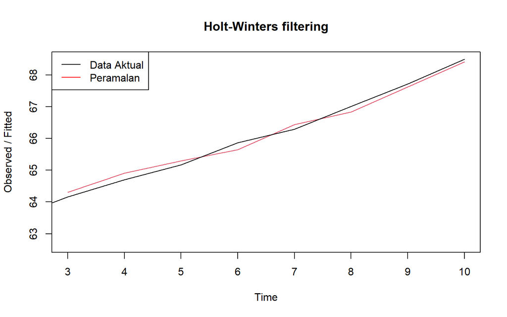

```r
plot(des.opt)
legend("topleft", c("Data Aktual", "Peramalan"), col = c("black", "red"),
       lty = c(1,1))
```

```r
#ramalan
ramalandesopt<- forecast(des.opt, h=5)
ramalandesopt
```

```
##    Point Forecast    Lo 80    Hi 80    Lo 95    Hi 95
## 11       69.25508 69.04282 69.46734 68.93045 69.57971
## 12       70.03743 69.64314 70.43171 69.43442 70.64043
## 13       70.81977 70.18427 71.45528 69.84785 71.79170
## 14       71.60212 70.68262 72.52163 70.19586 73.00838
## 15       72.38447 71.14531 73.62363 70.48934 74.27960
```

Selanjutnya akan dicari akurasi dari metode DES.

```r
ssedes.train<-des.opt$SSE
msedes.train<-ssedes.train/length(training.ts)
sisaandes<-ramalandesopt$residuals
head(sisaandes)
```

```
## Time Series:
## Start = 1
## End = 6
## Frequency = 1
## [1]         NA         NA -0.1500000 -0.2051934 -0.1265850  0.2095741
```

```r
mapedes.train <- sum(abs(sisaandes[3:length(training.ts)]/training.ts[3:length(training.ts)])*100)/length(training.ts)

akurasides.opt <- matrix(c(ssedes.train,msedes.train,mapedes.train))
row.names(akurasides.opt)<- c("SSE", "MSE", "MAPE")
colnames(akurasides.opt) <- c("Akurasi lamda dan gamma optimum")
akurasides.opt
```

```
##      Akurasi lamda dan gamma optimum
## SSE                       0.19249578
## MSE                       0.01924958
## MAPE                      0.17991246
```

```r
#Akurasi data testing
selisihdesopt<-ramalandesopt$mean-testing.ts
selisihdesopt
```

```
## Time Series:
## Start = 11
## End = 12
## Frequency = 1
## [1] 0.575079 1.037426
```

```r
SSEtestingdesopt<-sum(selisihdesopt^2)
SSEtestingdesopt<-SSEtestingdesopt/length(testing.ts)
MAPEtestingdesopt<-sum(abs(selisihdesopt/testing.ts)*100)/length(testing.ts)

akurasiDesTesting <- matrix(c(SSEtestingdesopt,SSEtestingdesopt,MAPEtestingdesopt))
row.names(akurasiDesTesting)<- c("SSE", "MSE", "MAPE")
colnames(akurasiDesTesting) <- c("Akurasi lamda dan gamma optimum")
akurasiDesTesting
```

```
##      Akurasi lamda dan gamma optimum
## SSE                        0.7034845
## MSE                        0.7034845
## MAPE                       1.1704237
```

Setelah didapatkan nilai akurasi untuk metode DMA dan DES, selanjutnya akan dibandingkan keakuratan antar metode keduanya.

```r
cbind(akurasi.dma, akurasides.opt)
```

```
##      Akurasi m = 3 Akurasi lamda dan gamma optimum
## SSE     0.59288889                      0.19249578
## MSE     0.08469841                      0.01924958
## MAPE    0.34238965                      0.17991246
```

Berdasarkan perbandingan akurasi tersebut, terlihat nilai SSE, MSE, dan MAPE metode DES lebih kecil dibandingkan dengan metode DMA. Oleh karena itu, metode peramalan dan pemulusan yang terbaik antara keduanya adalah dengan metode DES.

Setelah melakukan peramalan, data yang telah dimasukkan kemudian dieksplorasi. Eksplorasi pertama yang dilakukan adalah dengan menggunakan *scatter plot*.

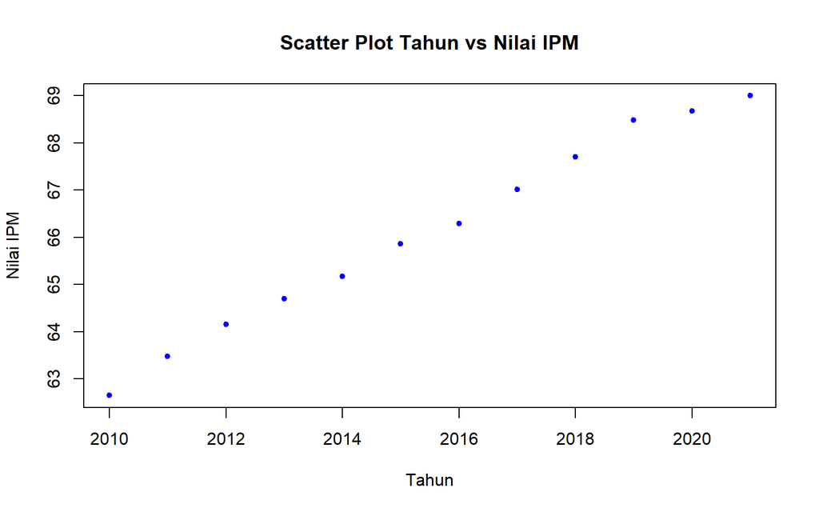

```r
#Eksplorasi Data
#Pembuatan Scatter Plot
plot(tahun,ipm, pch = 20, col = "blue",
     main = "Scatter Plot Tahun vs Nilai IPM",
     xlab = "Tahun",
     ylab = "Nilai IPM")
```

```r
#Menampilkan Nilai Korelasi
cor(tahun,ipm)
```

```
## [1] 0.9966848
```

Berdasarkan scatter plot di atas, terlihat adanya hubungan / korelasi positif antara peubah tahun dengan nilai IPM, terlihat titik-titik pada plot yang naik ke arah kanan atas. Hal tersebut juga diperkuat dengan hasil perhitungan aplikasi `R` di mana didapatkan nilai korelasi sebesar $0.9966848$.

Setalah mengetahui adanya hubungan antar dua peubah, maka model regresi dapat ditentukan.

## Regresi

```r
#Pembuatan Model Regresi
#model regresi
model<- lm(ipm~tahun, data = dtGorontalo)
summary(model)
```

```
##
## Call:
## lm(formula = ipm ~ tahun, data = dtGorontalo)
##
## Residuals:
##      Min       1Q   Median       3Q      Max
## -0.33000 -0.07295  0.02591  0.08000  0.33455
##
## Coefficients:
##               Estimate Std. Error t value Pr(>|t|)
## (Intercept) -1.118e+03  3.055e+01  -36.58 5.55e-12 ***
## tahun        5.873e-01  1.516e-02   38.74 3.14e-12 ***
## ---
## Signif. codes:  0 '***' 0.001 '**' 0.01 '*' 0.05 '.' 0.1 ' ' 1
##
## Residual standard error: 0.1813 on 10 degrees of freedom
## Multiple R-squared:  0.9934, Adjusted R-squared:  0.9927
## F-statistic:  1501 on 1 and 10 DF,  p-value: 3.136e-12
```

Model yang dihasilkan adalah
$$y_i=-1118+0.5873x_t$$
Berdasarkan ringkasan model dapat diketahui bahwa hasil uji F memiliki *p-value* < $\alpha$ (5%). Artinya, minimal terdapat satu variabel yang berpengaruh nyata terhadap model. Hasil uji-t parsial kedua parameter regresi, yaitu intersep dan koefisien regresi juga menunjukkan hal yang sama, yaitu memiliki *p-value* < $\alpha$ (5%) sehingga nyata dalam taraf 5%. Selanjutnya dapat dilihat juga nilai $R^2=0.9934$. Artinya, sebesar 99.34% keragaman nilai IPM dapat dijelaskan oleh peubah tahun. Hasil ini menunjukkan hasil yang bagus, seolah mendapatkan hasil terbaik. Namun, kita perlu melakukan uji terhadap sisaannya seperti berikut ini.

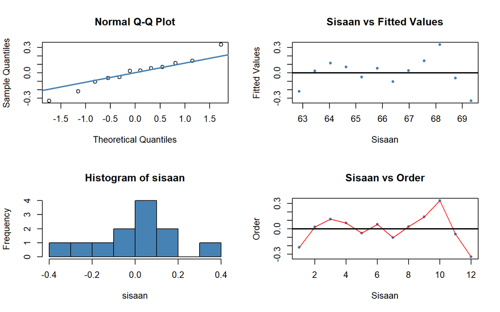

```r
#sisaan dan fitted value
sisaan<- residuals(model)
fitValue<- predict(model)

#Diagnostik dengan eksploratif
par(mfrow = c(2,2))
qqnorm(sisaan)
qqline(sisaan, col = "steelblue", lwd = 2)
plot(fitValue, sisaan, col = "steelblue", pch = 20, xlab = "Sisaan", ylab = "Fitted Values", main = "Sisaan vs Fitted Values")
abline(a = 0, b = 0, lwd = 2)
hist(sisaan, col = "steelblue")
plot(seq(1,12,1), sisaan, col = "steelblue", pch = 20, xlab = "Sisaan", ylab = "Order", main = "Sisaan vs Order")
lines(seq(1,12,1), sisaan, col = "red")
abline(a = 0, b = 0, lwd = 2)
```

Dua plot di samping kiri digunakan untuk melihat apakah sisaan menyebar normal. Normal Q-Q Plot di atas menunjukkan bahwa sisaan cenderung menyebar normal, tetapi histogram dari sisaan tidak menunjukkan demikian. Selanjutnya, dua plot di samping kanan digunakan untuk melihat autokorelasi. Plot Sisaan vs *Fitted Value* dan Plot Sisaan vs *Order* menunjukkan adanya pola pada sisaan. Untuk lebih lanjut akan digunakan uji formal melihat normalitas sisaan dan plot ACF dan PACF untuk melihat apakah ada autokorelasi atau tidak.

```r
#Melihat Sisaan Menyebar Normal/Tidak
#H0: sisaan mengikuti sebaran normal
#H1: sisaan tidak mengikuti sebaran normal
shapiro.test(sisaan)
```

```
##
##  Shapiro-Wilk normality test
##
## data:  sisaan
## W = 0.97479, p-value = 0.954
```

```r
ks.test(sisaan, "pnorm", mean=mean(sisaan), sd=sd(sisaan))
```

```
##
##  Exact one-sample Kolmogorov-Smirnov test
##
## data:  sisaan
## D = 0.13564, p-value = 0.9589
## alternative hypothesis: two-sided
```

Berdasarkan uji formal Saphiro-Wilk dan Kolmogorov-Smirnov didapatkan nilai *p-value* > $\alpha$ (5%). Artinya, cukup bukti untuk menyatakan sisaan berdistribusi normal.

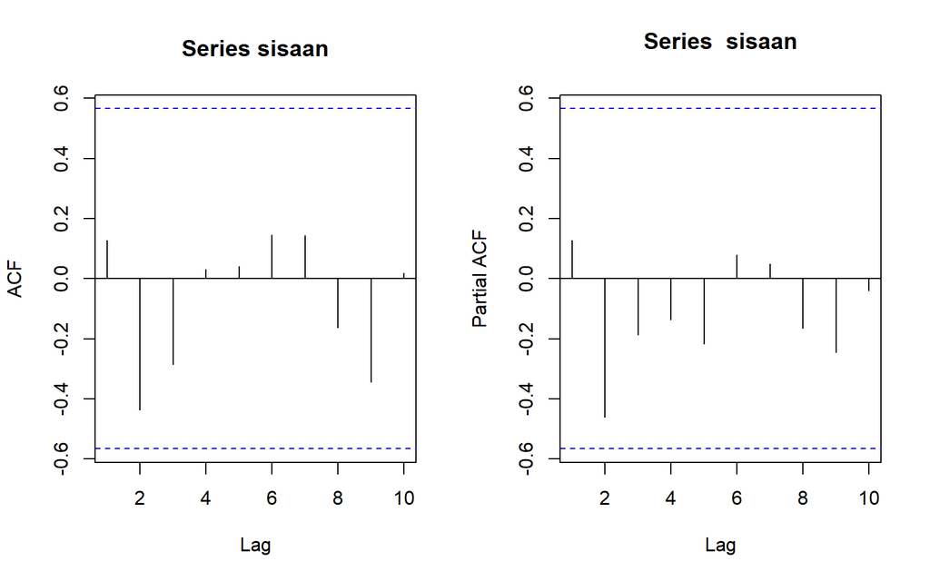

```r
#ACF dan PACF identifikasi autokorelasi
par(mfrow = c(1,2))
acf(sisaan)
pacf(sisaan)
```

Berdasarkan plot ACF dan PACF, terlihat semua dalam rentang batas dan tidak ada lag yang signifikan. Namun, untuk lebih memastikan akan dilakukan uji formal dengan uji Durbin Watson.

```r
#Deteksi autokorelasi dengan uji-Durbin Watson
#H0: tidak ada autokorelasi
#H1: ada autokorelasi
dwtest(model)
```

```
##
##  Durbin-Watson test
##
## data:  model
## DW = 1.2644, p-value = 0.03741
## alternative hypothesis: true autocorrelation is greater than 0
```

Berdasarkan hasil DW Test, didapatkan nilai $DW = 1.2644$ dan *p-value* = $0.03741$. Berdasarkan tabel Durbin-Watson diperoleh nilai $DL = 0.9771$ dan $DU = 1.331$. Nilai DW masih berada di antara nilai DL dan DU. Artinya, berada di daerah inkonklusif, tidak dapat dikatakan berada di daerah autokorelasi positif maupun bebas dari autokorelasi. Namun, dengan nilai *p-value* < 0.05 dapat disimpulkan bahwa tolak H0, cukup bukti mengatakan adanya autokorelasi. Oleh karena itu, diperlukan penangan autokorelasi. Penanganan yang akan digunakan menggunakan dua metode, yaitu Cochrane-Orcutt dan Hildret-Lu.

## Penanganan Autokorelasi

### Metode Cochrane-Orcutt

Penanganan metode Cochrane-Orcutt dapat dilakukan dengan bantuan packages Orcutt pada aplikasi `R` maupun secara manual. Berikut ini ditampilkan cara menggunakan bantuan `library` *packages* `Orcutt`.

```r
#Penanganan Autokorelasi Cochrane-Orcutt
modelCO<-cochrane.orcutt(model)
modelCO
```

```
## Cochrane-orcutt estimation for first order autocorrelation
##
## Call:
## lm(formula = ipm ~ tahun, data = dtGorontalo)
##
##  number of interaction: 30
##  rho 0.340921
##
## Durbin-Watson statistic
## (original):    1.26437 , p-value: 3.741e-02
## (transformed): 1.49014 , p-value: 9.403e-02
##
##  coefficients:
##  (Intercept)        tahun
## -1062.042646     0.559755
```

Hasil keluaran model setelah dilakukan penanganan adalah sebagai berikut.
$$y_i=-1062.042646+0.559755x_t$$
Hasil juga menunjukkan bahwa nilai DW dan p-value meningkat menjadi $1.49014$ dan $0.09403$. Nilai DW sudah berada pada rentang DU < DW < 4-DU atau $1.331 < DW < 2.669$. Hal tersebut juga didukung dengan nilai *p-value* > 0.05, artinya belum cukup bukti menyatakan bahwa sisaan terdapat autokorelasi pada taraf nyata 5%. Untuk nilai $ρ ̂$ optimum yang digunakan adalah $0.3409214$. Nilai tersebut dapat diketahui dengan *syntax* berikut.

```r
#Rho optimum
rho<- modelCO$rho
rho
```

```
## [1] 0.3409214
```

Selanjutnya akan dilakukan transformasi secara manual dengan syntax berikut ini.

```r
ipm
```

```
##  [1] 62.65 63.48 64.16 64.70 65.17 65.86 66.29 67.01 67.71 68.49 68.68 69.00
```

```r
ipm[-1]
```

```
##  [1] 63.48 64.16 64.70 65.17 65.86 66.29 67.01 67.71 68.49 68.68 69.00
```

```r
#Transformasi Manual
ipm.trans<- ipm[-1]-ipm[-12]*rho
tahun.trans<- tahun[-1]-tahun[-12]*rho
modelCOmanual<- lm(ipm.trans~tahun.trans)
summary(modelCOmanual)
```

```
##
## Call:
## lm(formula = ipm.trans ~ tahun.trans)
##
## Residuals:
##      Min       1Q   Median       3Q      Max
## -0.22770 -0.11619 -0.00273  0.05763  0.33083
##
## Coefficients:
##               Estimate Std. Error t value Pr(>|t|)
## (Intercept) -699.96956   31.38081  -22.31 3.46e-09 ***
## tahun.trans    0.55975    0.02361   23.71 2.02e-09 ***
## ---
## Signif. codes:  0 '***' 0.001 '**' 0.01 '*' 0.05 '.' 0.1 ' ' 1
##
## Residual standard error: 0.1632 on 9 degrees of freedom
## Multiple R-squared:  0.9842, Adjusted R-squared:  0.9825
## F-statistic:   562 on 1 and 9 DF,  p-value: 2.017e-09
```

Hasil model transformasi bukan merupakan model sesungguhnya. Koefisien regresi masih perlu dicari kembali mengikuti $β_0^*=β_0+ρ ̂β_0$ dan $β_1^*=β_1$.

```r
#Mencari Penduga Koefisien Regresi setelah Transformasi ke Persamaan Awal
b0bintang <- modelCOmanual$coefficients[-2]
b0 <- b0bintang/(1-rho)
b1 <- modelCOmanual$coefficients[-1]
b0
```

```
## (Intercept)
##   -1062.043
```

```r
b1
```

```
## tahun.trans
##   0.5597546
```

Hasil perhitungan koefisien regresi tersebut akan menghasilkan hasil yang sama dengan model yang dihasilkan menggunakan *packages*.

### Metode Hildreth-Lu

Penanganan kedua adalah menggunakan metode Hildreth-Lu. Metode ini akan mencari nilai SSE terkecil dan dapat dicari secara manual maupun menggunakan packages. Jika menggunakan packages, gunakan `library` *packages* `HORM`.

```r
#Penanganan Autokorelasi Hildreth lu
# Hildreth-Lu
hildreth.lu.func<- function(r, model){
  x <- model.matrix(model)[,-1]
  y <- model.response(model.frame(model))
  n <- length(y)
  t <- 2:n
  y <- y[t]-r*y[t-1]
  x <- x[t]-r*x[t-1]

  return(lm(y~x))
}

#Pencariab rho yang meminimumkan SSE
r <- c(seq(0.1,0.9, by= 0.1))
tab <- data.frame("rho" = r, "SSE" = sapply(r, function(i){deviance(hildreth.lu.func(i, model))}))
round(tab, 4)
```

```
##   rho    SSE
## 1 0.1 0.2499
## 2 0.2 0.2432
## 3 0.3 0.2400
## 4 0.4 0.2404
## 5 0.5 0.2442
## 6 0.6 0.2514
## 7 0.7 0.2622
## 8 0.8 0.2765
## 9 0.9 0.2942
```

Pertama-tama akan dicari di mana kira-kira $ρ$ yang menghasilkan SSE minimum. Pada hasil di atas terlihat $ρ$ minimum ketika 0.3. Namun, hasil tersebut masih kurang teliti sehingga akan dicari kembali $ρ$ yang lebih optimum dengan ketelitian yang lebih. Jika sebelumnya jarak antar $ρ$ yang dicari adalah 0.1, kali ini jarak antar $ρ$ adalah 0.001 dan dilakukan pada selang 0.2 sampai dengan 0.5.

```r
#Rho optimal di sekitar 0.4
rOpt <- seq(0.2,0.5, by= 0.001)
tabOpt <- data.frame("rho" = rOpt, "SSE" = sapply(rOpt, function(i){deviance(hildreth.lu.func(i, model))}))
head(tabOpt[order(tabOpt$SSE),])
```

```
##       rho       SSE
## 142 0.341 0.2397500
## 141 0.340 0.2397501
## 143 0.342 0.2397502
## 140 0.339 0.2397506
## 144 0.343 0.2397507
## 139 0.338 0.2397515
```

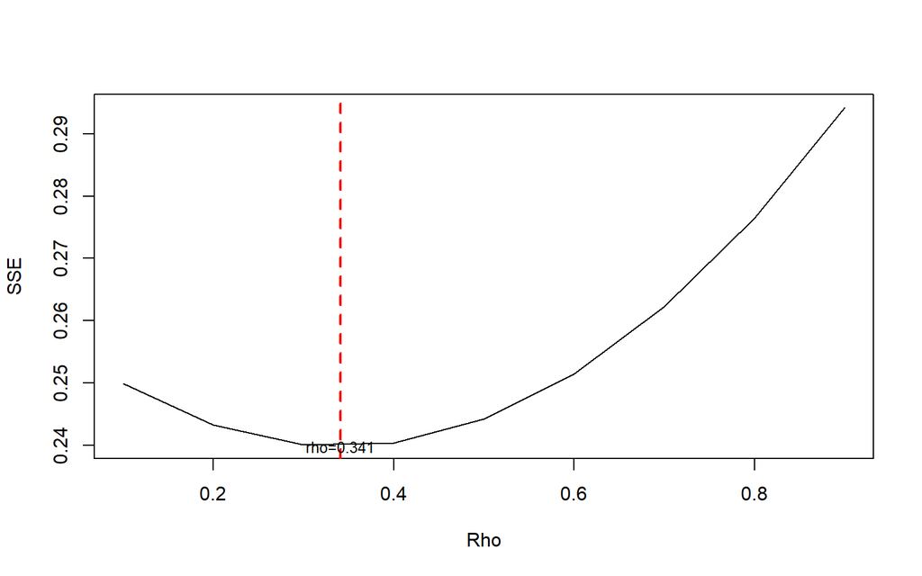

```r
#Grafik SSE optimum
par(mfrow = c(1,1))
plot(tab$SSE ~ tab$rho , type = "l", xlab = "Rho", ylab = "SSE")
abline(v = tabOpt[tabOpt$SSE==min(tabOpt$SSE),"rho"], lty = 2, col="red",lwd=2)
text(x=0.341, y=0.2397500, labels = "rho=0.341", cex = 0.8)
```

Perhitungan yang dilakukan aplikasi `R` menunjukkan bahwa nilai $ρ$ optimum, yaitu saat SSE terkecil terdapat pada nilai $ρ=0.341$. Hal tersebut juga ditunjukkan pada plot. Selanjutnya, model dapat didapatkan dengan mengevaluasi nilai $ρ$ ke dalam fungsi `hildreth.lu.func`, serta dilanjutkan dengan pengujian autokorelasi dengan uji Durbin-Watson. Namun, setelah pengecekan tersebut tidak lupa koefisien regresi tersebut digunakan untuk transformasi balik. Persamaan hasil transformasi itulah yang menjadi persamaan sesungguhnya.

```r
#Model terbaik
modelHL <- hildreth.lu.func(0.341, model)
summary(modelHL)
```

```
##
## Call:
## lm(formula = y ~ x)
##
## Residuals:
##      Min       1Q   Median       3Q      Max
## -0.22769 -0.11621 -0.00271  0.05763  0.33083
##
## Coefficients:
##               Estimate Std. Error t value Pr(>|t|)
## (Intercept) -699.87889   31.38081   -22.3 3.47e-09 ***
## x              0.55975    0.02361    23.7 2.02e-09 ***
## ---
## Signif. codes:  0 '***' 0.001 '**' 0.01 '*' 0.05 '.' 0.1 ' ' 1
##
## Residual standard error: 0.1632 on 9 degrees of freedom
## Multiple R-squared:  0.9842, Adjusted R-squared:  0.9825
## F-statistic: 561.9 on 1 and 9 DF,  p-value: 2.02e-09
```

```r
#Transformasi Balik
cat("y = ", coef(modelHL)[1]/(1-0.341), "+", coef(modelHL)[2],"x", sep = "")
```

```
## y = -1062.032+0.5597492x
```

Setelah dilakukan tranformasi balik, didapatkan model dengan metode Hildreth-Lu sebagai berikut.
$$y_i=-1062.032+0.5597492x_t$$

```r
#Deteksi autokorelasi
dwtest(modelHL)
```

```
##
##  Durbin-Watson test
##
## data:  modelHL
## DW = 1.4902, p-value = 0.09404
## alternative hypothesis: true autocorrelation is greater than 0
```

Terakhir, akan dibandingkan nilai SSE dari ketiga metode (metode awal, metode Cochrane-Orcutt, dan Hildreth-Lu).

```r
#Perbandingan
sseModelawal <- anova(model)$`Sum Sq`[-1]
sseModelCO <- anova(modelCOmanual)$`Sum Sq`[-1]
sseModelHL <- anova(modelHL)$`Sum Sq`[-1]
mseModelawal <- sseModelawal/length(ipm)
mseModelCO <- sseModelCO/length(ipm)
mseModelHL <- sseModelHL/length(ipm)
akurasi <- matrix(c(sseModelawal,sseModelCO,sseModelHL,
                    mseModelawal,mseModelCO,mseModelHL),nrow=2,ncol=3,byrow = T)
colnames(akurasi) <- c("Model Awal", "Model Cochrane-Orcutt", "Model Hildreth-Lu")
row.names(akurasi) <- c("SSE","MSE")
akurasi
```

```
##     Model Awal Model Cochrane-Orcutt Model Hildreth-Lu
## SSE 0.32863636            0.23974997        0.23974997
## MSE 0.02738636            0.01997916        0.01997916
```

Berdasarkan hasil tersebut dapat diketahui bahwa hasil penanganan autokorelasi dengan metode Cochrane-Orcutt dan Hildreth-Lu memiliki SSE yang sama, sebesar $0.23975$ dan lebih baik dibandingkan model awal ketika autokorelasi masih terjadi, yaitu sebesar $0.3286364$.

## Simpulan

Autokorelasi yang terdapat pada data IPM terjadi akibat adanya korelasi di antara unsur penyusunnya. Indikator IPM yang erat hubungannya dengan perekonomian sangat rawan menjadi penyebab adanya autokorelasi. Adanya autokorelasi menyebabkan model regresi kurang baik karena akan meingkatkan galatnya. Autokorelasi dapat dideteksi secara eksploratif melalui plot sisaan, ACF, dan PACF, serta dengan uji formal Durbin-Watson. Namun, autokorelasi tersebut dapat ditangani dengan metode Cochrane-Orcutt dan Hildreth-Lu. Kedua metode menghasilkan nilai SSE yang sama, artinya keduanya baik untuk digunakan.

# Pertemuan 3

## Library

```r
library(dLagM)
library(dynlm)
library(MLmetrics)
library(lmtest)
library(car)
```

## Impor Data

```r
data <- rio::import("https://raw.githubusercontent.com/rizkynurhambali/Praktikum-MPDW-2324/main/Pertemuan%203/Data%20Asli.csv")
str(data)
```

```
## 'data.frame':    20 obs. of  4 variables:
##  $ t     : int  1 2 3 4 5 6 7 8 9 10 ...
##  $ Yt    : num  52.9 53.8 54.9 58.2 60 63.4 68.2 78 84.7 90.6 ...
##  $ Y(t-1): num  NA 52.9 53.8 54.9 58.2 60 63.4 68.2 78 84.7 ...
##  $ Xt    : num  30.3 30.9 30.9 33.4 35.1 37.3 41 44.9 46.5 50.3 ...
```

```r
data
```

```
##     t    Yt Y(t-1)    Xt
## 1   1  52.9     NA  30.3
## 2   2  53.8   52.9  30.9
## 3   3  54.9   53.8  30.9
## 4   4  58.2   54.9  33.4
## 5   5  60.0   58.2  35.1
## 6   6  63.4   60.0  37.3
## 7   7  68.2   63.4  41.0
## 8   8  78.0   68.2  44.9
## 9   9  84.7   78.0  46.5
## 10 10  90.6   84.7  50.3
## 11 11  98.2   90.6  53.5
## 12 12 101.7   98.2  52.8
## 13 13 102.7  101.7  55.9
## 14 14 108.3  102.7  63.0
## 15 15 124.7  108.3  73.0
## 16 16 157.9  124.7  84.8
## 17 17 158.2  157.9  86.6
## 18 18 170.2  158.2  98.9
## 19 19 180.0  170.2 110.8
## 20 20 198.0  180.0 124.7
```

## Pembagian Data

```r
#SPLIT DATA
train<-data[1:15,]
test<-data[16:20,]
```

```r
#data time series
train.ts<-ts(train)
test.ts<-ts(test)
data.ts<-ts(data)
```

## Model Koyck

Model Koyck didasarkan pada asumsi bahwa semakin jauh jarak lag peubah independen dari periode sekarang maka semakin kecil pengaruh peubah lag terhadap peubah dependen.

Koyck mengusulkan suatu metode untuk menduga model dinamis distributed lag dengan mengasumsikan bahwa semua koefisien $\beta$ mempunyai tanda sama.

Model kyock merupakan jenis paling umum dari model infinite distributed lag dan juga dikenal sebagai geometric lag

$$y_t=a(1-\lambda)+\beta_0X_t+\beta_1Z_t+\lambda Y_{t-1}+V_t$$

dengan
$$V_t=u_t-\lambda
u_{t-1}$$

### Pemodelan

Pemodelan model Koyck dengan `R` dapat menggunakan `dLagM::koyckDlm()` . Fungsi umum dari `koyckDlm` adalah sebagai berikut.

```r
koyckDlm(x , y , intercept)
```

Fungsi `koyckDlm()` akan menerapkan model lag terdistribusi dengan transformasi Koyck satu prediktor. Nilai `x` dan `y` tidak perlu sebagai objek *time series* (`ts`). `intercept` dapat dibuat `TRUE` untuk memasukkan intersep ke dalam model.

```r
#MODEL KOYCK
model.koyck <- koyckDlm(x = train$Xt, y = train$Yt)
summary(model.koyck)
```

```
##
## Call:
## "Y ~ (Intercept) + Y.1 + X.t"
##
## Residuals:
##      Min       1Q   Median       3Q      Max
## -3.75605 -1.16407  0.01599  1.17295  3.28003
##
## Coefficients:
##             Estimate Std. Error t value Pr(>|t|)
## (Intercept)  -3.7335     2.1785  -1.714   0.1146
## Y.1           0.4214     0.1158   3.639   0.0039 **
## X.t           1.1510     0.1901   6.055 8.25e-05 ***
## ---
## Signif. codes:  0 '***' 0.001 '**' 0.01 '*' 0.05 '.' 0.1 ' ' 1
##
## Residual standard error: 2.023 on 11 degrees of freedom
## Multiple R-Squared: 0.9934,  Adjusted R-squared: 0.9922
## Wald test: 828.9 on 2 and 11 DF,  p-value: 1.01e-12
##
## Diagnostic tests:
## NULL
##
##                              alpha     beta       phi
## Geometric coefficients:  -6.452844 1.150951 0.4214181
```

```r
AIC(model.koyck)
```

```
## [1] 64.08525
```

```r
BIC(model.koyck)
```

```
## [1] 66.64148
```

Dari hasil tersebut, didapat bahwa peubah $x_t$ dan $y_{t-1}$ memiliki nilai $P-Value<0.05$. Hal ini menunjukkan bahwa peubah $x_t$ dan $y_{t-1}$ berpengaruh signifikan terhadap $y$. Adapun model keseluruhannya adalah sebagai berikut

$$\hat{Y_t}=-3.7335+1.1510X_t+0.4214Y_{t-1}$$

### Peramalan dan Akurasi

Berikut adalah hasil peramalan y untuk 5 periode kedepan menggunakan model koyck

```r
fore.koyck <- forecast(model = model.koyck, x=test$Xt, h=5)
fore.koyck
```

```
## $forecasts
## [1] 146.4180 157.6420 176.5288 198.1843 223.3085
##
## $call
## forecast.koyckDlm(model = model.koyck, x = test$Xt, h = 5)
##
## attr(,"class")
## [1] "forecast.koyckDlm" "dLagM"
```

```r
mape.koyck <- MAPE(fore.koyck$forecasts, test$Yt)
#akurasi data training
GoF(model.koyck)
```

```
##              n      MAE           MPE       MAPE      sMAPE      MASE      MSE
## model.koyck 14 1.473599 -0.0004874002 0.01720083 0.01719063 0.2701945 3.216237
##                  MRAE     GMRAE
## model.koyck 0.3967354 0.3026997
```

## Regression with Distributed Lag

Pemodelan model Regression with Distributed Lag dengan `R` dapat menggunakan `dLagM::dlm()` . Fungsi umum dari `dlm` adalah sebagai berikut.

```r
dlm(formula , data , x , y , q , remove )
```

Fungsi `dlm()` akan menerapkan model lag terdistribusi dengan satu atau lebih prediktor. Nilai `x` dan `y` tidak perlu sebagai objek *time series* (`ts`). $q$ adalah integer yang mewakili panjang *lag* yang terbatas.

### Pemodelan (Lag=2)

```r
model.dlm <- dlm(x = train$Xt,y = train$Yt , q = 2)
summary(model.dlm)
```

```
##
## Call:
## lm(formula = model.formula, data = design)
##
## Residuals:
##     Min      1Q  Median      3Q     Max
## -1.4446 -0.6965 -0.2373  0.8810  1.8630
##
## Coefficients:
##             Estimate Std. Error t value Pr(>|t|)
## (Intercept)  -9.6779     1.8156  -5.330 0.000474 ***
## x.t           0.3179     0.1792   1.774 0.109856
## x.1           1.5276     0.3487   4.380 0.001770 **
## x.2           0.2651     0.2440   1.087 0.305388
## ---
## Signif. codes:  0 '***' 0.001 '**' 0.01 '*' 0.05 '.' 0.1 ' ' 1
##
## Residual standard error: 1.322 on 9 degrees of freedom
## Multiple R-squared:  0.9974, Adjusted R-squared:  0.9965
## F-statistic:  1133 on 3 and 9 DF,  p-value: 6.471e-12
##
## AIC and BIC values for the model:
##       AIC      BIC
## 1 49.3705 52.19525
```

```r
AIC(model.dlm)
```

```
## [1] 49.3705
```

```r
BIC(model.dlm)
```

```
## [1] 52.19525
```

Dari hasil diatas, didapat bahwa $P-value$ dari intercept dan $x_{t-1}<0.05$. Hal ini menunjukkan bahwa intercept dan $x_{t-1}$ berpengaruh signifikan terhadap $y$. Adapun model keseluruhan yang terbentuk adalah sebagai berikut

$$\hat{Y_t}=-9.6779+0.3179X_t+1.5276X_{t-1}+0.2651X_{t-2}$$

### Peramalan dan Akurasi

Berikut merupakan hasil peramalan $y$ untuk 5 periode kedepan

```r
fore.dlm <- forecast(model = model.dlm, x=test$Xt, h=5)
fore.dlm
```

```
## $forecasts
## [1] 145.5021 166.7516 176.5405 199.5907 225.4498
##
## $call
## forecast.dlm(model = model.dlm, x = test$Xt, h = 5)
##
## attr(,"class")
## [1] "forecast.dlm" "dLagM"
```

```r
mape.dlm <- MAPE(fore.dlm$forecasts, test$Yt)
#akurasi data training
GoF(model.dlm)
```

```
##            n       MAE           MPE       MAPE      sMAPE      MASE      MSE
## model.dlm 13 0.9282513 -0.0002879026 0.01227837 0.01229574 0.1595847 1.210003
##                MRAE     GMRAE
## model.dlm 0.2350414 0.1491444
```

### *Lag* Optimum

```r
#penentuan lag optimum
finiteDLMauto(formula = Yt ~ Xt,
              data = data.frame(train), q.min = 1, q.max = 6,
              model.type = "dlm", error.type = "AIC", trace = FALSE)
```

```
##   q - k    MASE       AIC       BIC   GMRAE   MBRAE R.Adj.Sq Ljung-Box
## 6     6 0.00214 -29.87368 -28.09865 0.00225 0.00125  0.99999 0.9830642
```

Berdasarkan output tersebut, lag optimum didapatkan ketika lag=6. Selanjutnya dilakukan pemodelan untuk lag=6

```r
#model dlm dengan lag optimum
model.dlm2 <- dlm(x = train$Xt,y = train$Yt , q = 6)
summary(model.dlm2)
```

```
##
## Call:
## lm(formula = model.formula, data = design)
##
## Residuals:
##         1         2         3         4         5         6         7         8
## -0.023415  0.014375  0.032641 -0.010695 -0.013096 -0.014927  0.010054  0.010809
##         9
## -0.005747
##
## Coefficients:
##             Estimate Std. Error t value Pr(>|t|)
## (Intercept) 21.42223    1.44472  14.828   0.0429 *
## x.t          1.68749    0.04758  35.466   0.0179 *
## x.1         -1.23901    0.11688 -10.600   0.0599 .
## x.2          0.97604    0.02787  35.021   0.0182 *
## x.3         -0.23945    0.02746  -8.719   0.0727 .
## x.4          3.24431    0.14678  22.103   0.0288 *
## x.5          0.08560    0.04903   1.746   0.3312
## x.6         -3.47612    0.15157 -22.933   0.0277 *
## ---
## Signif. codes:  0 '***' 0.001 '**' 0.01 '*' 0.05 '.' 0.1 ' ' 1
##
## Residual standard error: 0.05079 on 1 degrees of freedom
## Multiple R-squared:      1,  Adjusted R-squared:      1
## F-statistic: 1.277e+05 on 7 and 1 DF,  p-value: 0.002155
##
## AIC and BIC values for the model:
##         AIC       BIC
## 1 -29.87368 -28.09865
```

```r
AIC(model.dlm2)
```

```
## [1] -29.87368
```

```r
BIC(model.dlm2)
```

```
## [1] -28.09865
```

Dari hasil tersebut terdapat beberapa peubah yang berpengaruh signifikan terhadap taraf nyata 5% yaitu $x_t$ , $x_{t-2}$ , $x_{t-4}$ , $x_{t-6}$. Adapun keseluruhan model yang terbentuk adalah

$$\hat{Y_t}=21.42223+1.68749X_t+...-3.47612X_{t-6}$$

Adapun hasil peramalan 5 periode kedepan menggunakan model tersebut adalah sebagai berikut

```r
#peramalan dan akurasi
fore.dlm2 <- forecast(model = model.dlm2, x=test$Xt, h=5)
mape.dlm2<- MAPE(fore.dlm2$forecasts, test$Yt)
#akurasi data training
GoF(model.dlm2)
```

```
##            n        MAE           MPE         MAPE        sMAPE        MASE
## model.dlm2 9 0.01508446 -2.246354e-06 0.0001727757 0.0001727773 0.002135853
##                     MSE        MRAE       GMRAE
## model.dlm2 0.0002866713 0.003309313 0.002245928
```

Model tersebut merupakan model yang sangat baik dengan nilai MAPE yang kurang dari 10%.

## Model Autoregressive

Peubah dependen dipengaruhi oleh peubah independen pada waktu sekarang, serta dipengaruhi juga oleh peubah dependen itu sendiri pada satu waktu yang lalu maka model tersebut disebut *autoregressive* (Gujarati 2004).

### Pemodelan

Pemodelan Autoregressive dilakukan menggunakan fungsi `dLagM::ardlDlm()` . Fungsi tersebut akan menerapkan *autoregressive* berordo $(p,q)$ dengan satu prediktor. Fungsi umum dari `ardlDlm()` adalah sebagai berikut.

```r
ardlDlm(formula = NULL , data = NULL , x = NULL , y = NULL , p = 1 , q = 1 ,
         remove = NULL )
```

Dengan $p$ adalah integer yang mewakili panjang *lag* yang terbatas dan $q$ adalah integer yang merepresentasikan ordo dari proses *autoregressive*.

```r
#model.ardl <- ardlDlm(x = train$Xt, y = train$Yt, p = 1 , q = 1)
#summary(model.ardl)
#AIC(model.ardl)
#BIC(model.ardl)
```

```r
model.ardl <- ardlDlm(formula = Yt ~ Xt,
                         data = train,p = 1 , q = 1)
summary(model.ardl)
```

```
##
## Time series regression with "ts" data:
## Start = 2, End = 15
##
## Call:
## dynlm(formula = as.formula(model.text), data = data)
##
## Residuals:
##     Min      1Q  Median      3Q     Max
## -1.6274 -0.8401 -0.1767  0.8392  1.9447
##
## Coefficients:
##             Estimate Std. Error t value Pr(>|t|)
## (Intercept)  -8.3594     1.9186  -4.357  0.00143 **
## Xt.t          0.3563     0.1875   1.900  0.08661 .
## Xt.1          1.4557     0.4071   3.575  0.00505 **
## Yt.1          0.1408     0.1318   1.068  0.31055
## ---
## Signif. codes:  0 '***' 0.001 '**' 0.01 '*' 0.05 '.' 0.1 ' ' 1
##
## Residual standard error: 1.269 on 10 degrees of freedom
## Multiple R-squared:  0.9976, Adjusted R-squared:  0.9969
## F-statistic:  1405 on 3 and 10 DF,  p-value: 2.006e-13
```

```r
AIC(model.ardl)
```

```
## [1] 51.69462
```

```r
BIC(model.ardl)
```

```
## [1] 54.8899
```

$$\hat{Y}=-8,3594+0,3563X_t+1,4557X_{t-1}+0,1408Y_{t-1}$$

### Peramalan dan Akurasi

```r
fore.ardl <- forecast(model = model.ardl, x=test$Xt, h=5)
fore.ardl
```

```
## $forecasts
## [1] 145.6865 166.4608 176.3897 199.9337 225.5255
##
## $call
## forecast.ardlDlm(model = model.ardl, x = test$Xt, h = 5)
##
## attr(,"class")
## [1] "forecast.ardlDlm" "dLagM"
```

Data di atas merupakan hasil peramalan untuk 5 periode ke depan menggunakan Model Autoregressive dengan $p=1$ dan $q=1$.

```r
mape.ardl <- MAPE(fore.ardl$forecasts, test$Yt)
mape.ardl
```

```
## [1] 0.08313896
```

```r
#akurasi data training
GoF(model.ardl)
```

```
##             n       MAE           MPE       MAPE      sMAPE      MASE     MSE
## model.ardl 14 0.8821232 -0.0003216464 0.01183235 0.01185341 0.1617433 1.15063
##                 MRAE     GMRAE
## model.ardl 0.2332582 0.1391987
```

### *Lag* Optimum

```r
#penentuan lag optimum
model.ardl.opt <- ardlBoundOrders(data = data.frame(data), ic = "AIC",
                                  formula = Yt ~ Xt )
min_p=c()
for(i in 1:6){
  min_p[i]=min(model.ardl.opt$Stat.table[[i]])
}
q_opt=which(min_p==min(min_p, na.rm = TRUE))
p_opt=which(model.ardl.opt$Stat.table[[q_opt]] ==
              min(model.ardl.opt$Stat.table[[q_opt]], na.rm = TRUE))
data.frame("q_optimum" = q_opt, "p_optimum" = p_opt,
           "AIC"=model.ardl.opt$min.Stat)
```

```
##   q_optimum p_optimum       AIC
## 1         1         6 -20.56587
```

Dari tabel di atas, dapat terlihat bahwa nilai AIC terendah didapat ketika $p=6$ dan $q=1$, yaitu sebesar `-20,56587`. Artinya, model autoregressive optimum didapat ketika $p=6$ dan $q=1$.

Selanjutnya dapat dilakukan pemodelan dengan nilai $p$ dan $q$ optimum seperti inisialisasi di langkah sebelumnya.

## Pemodelan DLM & ARDL dengan Library `dynlm`

Pemodelan regresi dengan peubah *lag* tidak hanya dapat dilakukan dengan fungsi pada *packages* `dLagM` , tetapi terdapat *packages* `dynlm` yang dapat digunakan. Fungsi `dynlm` secara umum adalah sebagai berikut.

```r
dynlm(formula, data, subset, weights, na.action, method = "qr",
  model = TRUE, x = FALSE, y = FALSE, qr = TRUE, singular.ok = TRUE,
  contrasts = NULL, offset, start = NULL, end = NULL, ...)
```

Untuk menentukan `formula` model yang akan digunakan, tersedia fungsi tambahan yang memungkinkan spesifikasi dinamika (melalui `d()` dan `L()`) atau pola linier/siklus dengan mudah (melalui `trend()`, `season()`, dan `harmon()`). Semua fungsi formula baru mengharuskan argumennya berupa objek deret waktu (yaitu, `"ts"` atau `"zoo"`).

```r
#sama dengan model dlm q=1
cons_lm1 <- dynlm(Yt ~ Xt+L(Xt),data = train.ts)
#sama dengan model ardl p=1 q=0
cons_lm2 <- dynlm(Yt ~ Xt+L(Yt),data = train.ts)
#sama dengan ardl p=1 q=1
cons_lm3 <- dynlm(Yt ~ Xt+L(Xt)+L(Yt),data = train.ts)
#sama dengan dlm p=2
cons_lm4 <- dynlm(Yt ~ Xt+L(Xt)+L(Xt,2),data = train.ts)
```

### Ringkasan Model

```r
summary(cons_lm1)
```

```
##
## Time series regression with "ts" data:
## Start = 2, End = 15
##
## Call:
## dynlm(formula = Yt ~ Xt + L(Xt), data = train.ts)
##
## Residuals:
##     Min      1Q  Median      3Q     Max
## -1.4118 -0.8790 -0.3542  0.7202  2.3047
##
## Coefficients:
##             Estimate Std. Error t value Pr(>|t|)
## (Intercept)  -9.4870     1.6123  -5.884 0.000106 ***
## Xt            0.2557     0.1632   1.567 0.145434
## L(Xt)         1.8395     0.1927   9.547 1.17e-06 ***
## ---
## Signif. codes:  0 '***' 0.001 '**' 0.01 '*' 0.05 '.' 0.1 ' ' 1
##
## Residual standard error: 1.277 on 11 degrees of freedom
## Multiple R-squared:  0.9974, Adjusted R-squared:  0.9969
## F-statistic:  2081 on 2 and 11 DF,  p-value: 6.538e-15
```

```r
summary(cons_lm2)
```

```
##
## Time series regression with "ts" data:
## Start = 2, End = 15
##
## Call:
## dynlm(formula = Yt ~ Xt + L(Yt), data = train.ts)
##
## Residuals:
##     Min      1Q  Median      3Q     Max
## -3.4441 -1.1436  0.1785  1.5549  2.1584
##
## Coefficients:
##             Estimate Std. Error t value Pr(>|t|)
## (Intercept) -3.54096    1.96526  -1.802    0.099 .
## Xt           0.92218    0.14482   6.368 5.31e-05 ***
## L(Yt)        0.55684    0.08922   6.241 6.34e-05 ***
## ---
## Signif. codes:  0 '***' 0.001 '**' 0.01 '*' 0.05 '.' 0.1 ' ' 1
##
## Residual standard error: 1.827 on 11 degrees of freedom
## Multiple R-squared:  0.9946, Adjusted R-squared:  0.9936
## F-statistic:  1015 on 2 and 11 DF,  p-value: 3.344e-13
```

```r
summary(cons_lm3)
```

```
##
## Time series regression with "ts" data:
## Start = 2, End = 15
##
## Call:
## dynlm(formula = Yt ~ Xt + L(Xt) + L(Yt), data = train.ts)
##
## Residuals:
##     Min      1Q  Median      3Q     Max
## -1.6274 -0.8401 -0.1767  0.8392  1.9447
##
## Coefficients:
##             Estimate Std. Error t value Pr(>|t|)
## (Intercept)  -8.3594     1.9186  -4.357  0.00143 **
## Xt            0.3563     0.1875   1.900  0.08661 .
## L(Xt)         1.4557     0.4071   3.575  0.00505 **
## L(Yt)         0.1408     0.1318   1.068  0.31055
## ---
## Signif. codes:  0 '***' 0.001 '**' 0.01 '*' 0.05 '.' 0.1 ' ' 1
##
## Residual standard error: 1.269 on 10 degrees of freedom
## Multiple R-squared:  0.9976, Adjusted R-squared:  0.9969
## F-statistic:  1405 on 3 and 10 DF,  p-value: 2.006e-13
```

```r
summary(cons_lm4)
```

```
##
## Time series regression with "ts" data:
## Start = 3, End = 15
##
## Call:
## dynlm(formula = Yt ~ Xt + L(Xt) + L(Xt, 2), data = train.ts)
##
## Residuals:
##     Min      1Q  Median      3Q     Max
## -1.4446 -0.6965 -0.2373  0.8810  1.8630
##
## Coefficients:
##             Estimate Std. Error t value Pr(>|t|)
## (Intercept)  -9.6779     1.8156  -5.330 0.000474 ***
## Xt            0.3179     0.1792   1.774 0.109856
## L(Xt)         1.5276     0.3487   4.380 0.001770 **
## L(Xt, 2)      0.2651     0.2440   1.087 0.305388
## ---
## Signif. codes:  0 '***' 0.001 '**' 0.01 '*' 0.05 '.' 0.1 ' ' 1
##
## Residual standard error: 1.322 on 9 degrees of freedom
## Multiple R-squared:  0.9974, Adjusted R-squared:  0.9965
## F-statistic:  1133 on 3 and 9 DF,  p-value: 6.471e-12
```

### SSE

```r
deviance(cons_lm1)
```

```
## [1] 17.94685
```

```r
deviance(cons_lm2)
```

```
## [1] 36.70155
```

```r
deviance(cons_lm3)
```

```
## [1] 16.10882
```

```r
deviance(cons_lm4)
```

```
## [1] 15.73004
```

### Uji Diagnostik

```r
#uji model
if(require("lmtest")) encomptest(cons_lm1, cons_lm2)
```

```
## Encompassing test
##
## Model 1: Yt ~ Xt + L(Xt)
## Model 2: Yt ~ Xt + L(Yt)
## Model E: Yt ~ Xt + L(Xt) + L(Yt)
##           Res.Df Df      F  Pr(>F)
## M1 vs. ME     10 -1  1.141 0.31055
## M2 vs. ME     10 -1 12.784 0.00505 **
## ---
## Signif. codes:  0 '***' 0.001 '**' 0.01 '*' 0.05 '.' 0.1 ' ' 1
```

#### Autokorelasi

```r
#durbin watson
dwtest(cons_lm1)
```

```
##
##  Durbin-Watson test
##
## data:  cons_lm1
## DW = 2.1065, p-value = 0.3842
## alternative hypothesis: true autocorrelation is greater than 0
```

```r
dwtest(cons_lm2)
```

```
##
##  Durbin-Watson test
##
## data:  cons_lm2
## DW = 1.441, p-value = 0.0497
## alternative hypothesis: true autocorrelation is greater than 0
```

```r
dwtest(cons_lm3)
```

```
##
##  Durbin-Watson test
##
## data:  cons_lm3
## DW = 1.9337, p-value = 0.2449
## alternative hypothesis: true autocorrelation is greater than 0
```

```r
dwtest(cons_lm4)
```

```
##
##  Durbin-Watson test
##
## data:  cons_lm4
## DW = 1.8189, p-value = 0.1911
## alternative hypothesis: true autocorrelation is greater than 0
```

#### Heterogenitas

```r
bptest(cons_lm1)
```

```
##
##  studentized Breusch-Pagan test
##
## data:  cons_lm1
## BP = 1.5713, df = 2, p-value = 0.4558
```

```r
bptest(cons_lm2)
```

```
##
##  studentized Breusch-Pagan test
##
## data:  cons_lm2
## BP = 3.7022, df = 2, p-value = 0.1571
```

```r
bptest(cons_lm3)
```

```
##
##  studentized Breusch-Pagan test
##
## data:  cons_lm3
## BP = 4.0554, df = 3, p-value = 0.2555
```

```r
bptest(cons_lm4)
```

```
##
##  studentized Breusch-Pagan test
##
## data:  cons_lm4
## BP = 2.7921, df = 3, p-value = 0.4248
```

#### Kenormalan

```r
shapiro.test(residuals(cons_lm1))
```

```
##
##  Shapiro-Wilk normality test
##
## data:  residuals(cons_lm1)
## W = 0.90752, p-value = 0.145
```

```r
shapiro.test(residuals(cons_lm2))
```

```
##
##  Shapiro-Wilk normality test
##
## data:  residuals(cons_lm2)
## W = 0.94358, p-value = 0.4661
```

```r
shapiro.test(residuals(cons_lm3))
```

```
##
##  Shapiro-Wilk normality test
##
## data:  residuals(cons_lm3)
## W = 0.94403, p-value = 0.4723
```

```r
shapiro.test(residuals(cons_lm4))
```

```
##
##  Shapiro-Wilk normality test
##
## data:  residuals(cons_lm4)
## W = 0.92477, p-value = 0.2907
```

## Perbandingan Model

```r
akurasi <- matrix(c(mape.koyck, mape.dlm, mape.dlm2, mape.ardl))
row.names(akurasi)<- c("Koyck","DLM 1","DLM 2","Autoregressive")
colnames(akurasi) <- c("MAPE")
akurasi
```

```
##                      MAPE
## Koyck          0.06845456
## DLM 1          0.08345978
## DLM 2          0.15117526
## Autoregressive 0.08313896
```

Berdasarkan nilai MAPE, model paling optimum didapat pada Model Koyck karena memiliki nilai MAPE yang terkecil.

### Plot

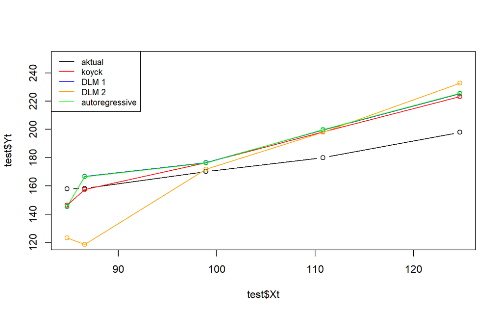

```r
par(mfrow=c(1,1))
plot(test$Xt, test$Yt, type="b", col="black", ylim=c(120,250))
points(test$Xt, fore.koyck$forecasts,col="red")
lines(test$Xt, fore.koyck$forecasts,col="red")
points(test$Xt, fore.dlm$forecasts,col="blue")
lines(test$Xt, fore.dlm$forecasts,col="blue")
points(test$Xt, fore.dlm2$forecasts,col="orange")
lines(test$Xt, fore.dlm2$forecasts,col="orange")
points(test$Xt, fore.ardl$forecasts,col="green")
lines(test$Xt, fore.ardl$forecasts,col="green")
legend("topleft",c("aktual", "koyck","DLM 1","DLM 2", "autoregressive"), lty=1, col=c("black","red","blue","orange","green"), cex=0.8)
```

Berdasarkan plot tersebut, terlihat bahwa plot yang paling mendekati data aktualnya adalah Model koyck, sehingga dapat disimpulkan model terbaik dalam hal ini adalah model regresi koyck

## Pengayaan (Regresi Berganda)

### Data

```r
data(M1Germany)
data1 = M1Germany[1:144,]
```

### DLM

```r
#Run the search over finite DLMs according to AIC values
finiteDLMauto(formula = logprice ~ interest+logm1,
              data = data.frame(data1), q.min = 1, q.max = 5,
              model.type = "dlm", error.type = "AIC", trace = FALSE)
```

```
##   q - k    MASE       AIC       BIC   GMRAE    MBRAE R.Adj.Sq Ljung-Box
## 5     5 1.77163 -463.1393 -422.0566 1.43662 -1.60494  0.98836         0
```

```r
#model dlm berganda
model.dlmberganda = dlm(formula = logprice ~ interest + logm1,
                data = data.frame(data1) , q = 5)
summary(model.dlmberganda)
```

```
##
## Call:
## lm(formula = as.formula(model.formula), data = design)
##
## Residuals:
##       Min        1Q    Median        3Q       Max
## -0.095761 -0.028610 -0.000012  0.029496  0.102597
##
## Coefficients:
##             Estimate Std. Error t value Pr(>|t|)
## (Intercept) -7.81759    0.11384 -68.669  < 2e-16 ***
## interest.t  -1.75616    0.80358  -2.185 0.030707 *
## interest.1   1.38935    1.22707   1.132 0.259679
## interest.2   0.40776    1.23726   0.330 0.742273
## interest.3   1.23130    1.20752   1.020 0.309830
## interest.4  -0.08718    1.20869  -0.072 0.942616
## interest.5   3.06850    0.89380   3.433 0.000808 ***
## logm1.t      0.43219    0.20876   2.070 0.040474 *
## logm1.1      0.42190    0.19807   2.130 0.035109 *
## logm1.2      0.20943    0.12883   1.626 0.106532
## logm1.3      0.22053    0.13011   1.695 0.092567 .
## logm1.4      0.05513    0.21457   0.257 0.797633
## logm1.5      0.03042    0.19192   0.159 0.874296
## ---
## Signif. codes:  0 '***' 0.001 '**' 0.01 '*' 0.05 '.' 0.1 ' ' 1
##
## Residual standard error: 0.04343 on 126 degrees of freedom
## Multiple R-squared:  0.9894, Adjusted R-squared:  0.9884
## F-statistic: 977.9 on 12 and 126 DF,  p-value: < 2.2e-16
##
## AIC and BIC values for the model:
##         AIC       BIC
## 1 -463.1393 -422.0566
```

```r
model.dlmberganda2 = dlm(formula = logprice ~ interest + logm1,
                        data = data.frame(data1) , q = 1)
summary(model.dlmberganda2)
```

```
##
## Call:
## lm(formula = as.formula(model.formula), data = design)
##
## Residuals:
##       Min        1Q    Median        3Q       Max
## -0.134002 -0.044697  0.006407  0.036962  0.113063
##
## Coefficients:
##             Estimate Std. Error t value Pr(>|t|)
## (Intercept) -7.77917    0.13299 -58.492  < 2e-16 ***
## interest.t  -3.22103    0.94184  -3.420 0.000824 ***
## interest.1   6.52775    0.94501   6.908 1.66e-10 ***
## logm1.t      0.73918    0.08419   8.780 5.61e-15 ***
## logm1.1      0.63330    0.08429   7.513 6.55e-12 ***
## ---
## Signif. codes:  0 '***' 0.001 '**' 0.01 '*' 0.05 '.' 0.1 ' ' 1
##
## Residual standard error: 0.05443 on 138 degrees of freedom
## Multiple R-squared:  0.9832, Adjusted R-squared:  0.9828
## F-statistic:  2025 on 4 and 138 DF,  p-value: < 2.2e-16
##
## AIC and BIC values for the model:
##         AIC       BIC
## 1 -419.7575 -401.9805
```

### ARDL

```r
#Mencari orde lag optimum model ARDL
ardlBoundOrders(data = data1 , formula = logprice ~ interest + logm1,
                ic="AIC")
```

```
## $p
##    interest logm1
## 65        0     4
##
## $q
## [1] 4
##
## $Stat.table
##            q = 1     q = 2     q = 3     q = 4     q = 5     q = 6     q = 7
## p = 1  -760.1786 -757.9195 -846.8342 -975.2079 -965.7536 -958.9072 -956.7315
## p = 2  -760.0433 -759.3090 -843.6247 -971.2514 -961.7929 -955.2809 -953.4890
## p = 3  -753.7746 -753.7746 -841.2485 -970.4543 -961.4343 -953.7173 -950.0412
## p = 4  -829.8076 -832.6436 -832.6436 -971.0837 -962.1804 -955.0429 -953.4667
## p = 5  -749.4144 -753.2292 -962.9290 -962.9290 -961.7063 -954.3406 -951.7660
## p = 6  -742.2103 -742.9945 -891.6195 -952.3771 -952.3771 -952.2461 -950.1105
```

[output cut: 302 more lines]

```r
model.ardlDlmberganda = ardlDlm(formula = logprice ~ interest + logm1,
                        data = data.frame(data1) , p = 4 , q = 4)
summary(model.ardlDlmberganda)
```

```
##
## Time series regression with "ts" data:
## Start = 5, End = 144
##
## Call:
## dynlm(formula = as.formula(model.text), data = data)
##
## Residuals:
##        Min         1Q     Median         3Q        Max
## -0.0290527 -0.0075965  0.0005726  0.0072745  0.0304486
##
## Coefficients:
##               Estimate Std. Error t value Pr(>|t|)
## (Intercept)  0.0145022  0.1822785   0.080  0.93671
## interest.t   0.0067985  0.2135315   0.032  0.97465
## interest.1   0.6093502  0.3240545   1.880  0.06238 .
## interest.2   0.0798544  0.3221168   0.248  0.80461
## interest.3  -0.3638172  0.3238873  -1.123  0.26347
## interest.4   0.2084240  0.2447331   0.852  0.39604
## logm1.t      0.0828689  0.0457486   1.811  0.07248 .
## logm1.1     -0.0092841  0.0399079  -0.233  0.81642
## logm1.2     -0.1166129  0.0390732  -2.984  0.00342 **
## logm1.3      0.0007016  0.0389297   0.018  0.98565
## logm1.4      0.0447857  0.0425474   1.053  0.29455
## logprice.1   0.3274245  0.0651574   5.025  1.7e-06 ***
## logprice.2   0.1323801  0.0684485   1.934  0.05537 .
## logprice.3  -0.1448245  0.0674268  -2.148  0.03365 *
## logprice.4   0.6730871  0.0636443  10.576  < 2e-16 ***
## ---
## Signif. codes:  0 '***' 0.001 '**' 0.01 '*' 0.05 '.' 0.1 ' ' 1
##
## Residual standard error: 0.01132 on 125 degrees of freedom
## Multiple R-squared:  0.9993, Adjusted R-squared:  0.9992
## F-statistic: 1.273e+04 on 14 and 125 DF,  p-value: < 2.2e-16
```

```r
#model p interest 0 p logm1 4
rem.p = list(interest = c(1,2,3,4))
remove = list(p = rem.p)
model.ardlDlmberganda2 = ardlDlm(formula = logprice ~ interest + logm1,
                        data = data.frame(data1) , p = 4 , q = 4 ,
                        remove = remove)
summary(model.ardlDlmberganda2)
```

```
##
## Time series regression with "ts" data:
## Start = 5, End = 144
##
## Call:
## dynlm(formula = as.formula(model.text), data = data)
##
## Residuals:
##        Min         1Q     Median         3Q        Max
## -0.0290369 -0.0083445  0.0009024  0.0079199  0.0303652
##
## Coefficients:
##              Estimate Std. Error t value Pr(>|t|)
## (Intercept)  0.174838   0.133708   1.308  0.19333
## interest.t   0.448826   0.098736   4.546 1.24e-05 ***
## logm1.t      0.056659   0.043836   1.293  0.19849
## logm1.1     -0.017025   0.039159  -0.435  0.66446
## logm1.2     -0.118413   0.037399  -3.166  0.00193 **
## logm1.3     -0.006454   0.038112  -0.169  0.86580
## logm1.4      0.060220   0.040337   1.493  0.13789
## logprice.1   0.319059   0.062107   5.137 1.00e-06 ***
## logprice.2   0.111794   0.066101   1.691  0.09320 .
## logprice.3  -0.122129   0.065114  -1.876  0.06297 .
## logprice.4   0.699061   0.062611  11.165  < 2e-16 ***
## ---
## Signif. codes:  0 '***' 0.001 '**' 0.01 '*' 0.05 '.' 0.1 ' ' 1
##
## Residual standard error: 0.01149 on 129 degrees of freedom
## Multiple R-squared:  0.9993, Adjusted R-squared:  0.9992
## F-statistic: 1.73e+04 on 10 and 129 DF,  p-value: < 2.2e-16
```

Proses selanjutnya sama dengan pemodelan menggunakan peubah tunggal.

# Pertemuan 4

## White Noise

Pembangkitan data berpola AR, MA, ARMA, dan banyak proses deret waktu lainnya diawali pembangkitan *white noise*. *White noise* merupakan sederet nilai dari peubah bebas stokastik identik. Oleh karena itu, *white noise* memiliki dua karakteristik penting:

1. *White noise* tidak memiliki autokorelasi (**karena saling bebas**)
2. Nilai harapan dan ragam *white noise* sama (**karena berasal dari peubah acak bebas stokastik identik**)

*White noise* dibangkitkan dari suatu peubah acak, umumnya peubah acak normal.

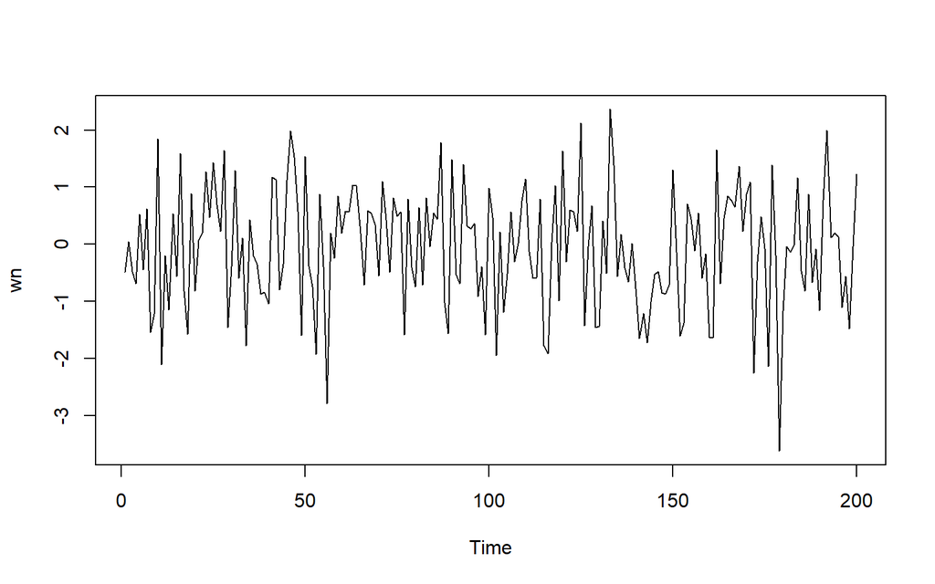

```r
wn <- rnorm(200)
ts.plot(wn)
```

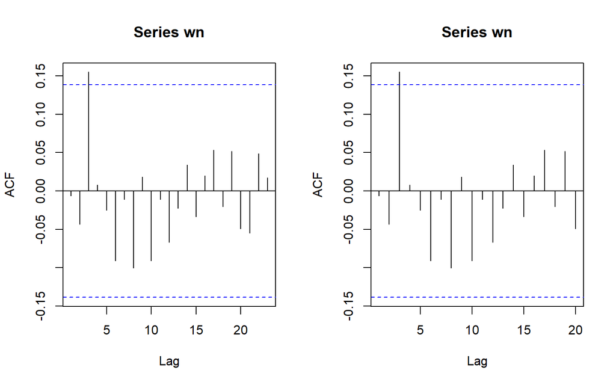

```r
par(mfrow = c(1, 2))
acf(wn)
acf(wn, xlim = c(1, 20))
```

## Proses MA

Proses MA dapat dituliskan sebagai berikut:

$$y_{t} = c + e_t + \theta_{1}e_{t-1} + \theta_{2}e_{t-2} + \dots +
\theta_{q}e_{t-q} = c+{e_t+\sum_{i=1}^p \theta_ie_{t-i}}$$
Terlihat bahwa $e_t$, atau *white noise*, berperan penting dalam pembangkitan proses MA.

## Pembangkitan Proses MA(1)

Akan dicoba membangkitkan proses MA paling sederhana, yaitu MA(1) dengan $\theta = 0.5$ sebanyak 200 observasi dan $c=0$. Karena diperlukan satu nilai awal untuk $e_{t-1}$, masukkan nilai pertama white noise sebagai nilai awal tersebut.

```r
set.seed(1234)
ma <- wn[1]
```

Nilai-nilai selanjutnya dapat dicari melalui *loop*. Bentuk loop dapat dilihat dari rumus MA(1) yang hendak dibangkitkan:

$$y_t = e_t+0.5e_{t-1}$$

```r
for(i in 2:200){
   ma[i] <- wn[i] + 0.5 * wn[i - 1]
}
ma
```

```
##   [1] -0.486997705 -0.197160026 -0.456788931 -0.931629323  0.180381656
##   [6] -0.180812561  0.396757822 -1.229652878 -1.985037549  1.241942041
##  [11] -1.183445228 -1.252621403 -1.249719968 -0.034234335 -0.288368817
##  [16]  1.309655437 -0.022614750 -1.983772082  0.099558539 -0.368055551
##  [21] -0.340285573  0.224565765  1.363834927  1.110757150  1.666265253
##  [26]  1.411178742  0.575372338  1.760131976 -0.636457358 -1.123802192
##  [31]  1.096555980  0.052812425 -0.183840872 -1.717377666 -0.451912690
##  [36]  0.020623628 -0.442261802 -1.036189945 -1.268660896 -1.455381392
##  [41]  0.659392571  1.718539903 -0.225013773 -0.747246494  0.941884534
##  [46]  2.542921770  2.518131274  1.347119529 -1.296823215  0.746890529
##  [51]  0.388238525 -0.937276032 -2.292858987 -0.087380873  0.041127553
##  [56] -2.980989405 -1.200198847 -0.147999864  0.722976379  0.614649282
##  [61]  0.672033591  0.851562851  1.315679167  1.544064687  0.714323435
##  [66] -0.611479793  0.228265828  0.825923148  0.607482077 -0.384150365
##  [71]  0.827736222  0.977248356 -0.274909583  0.567501143  0.894856079
```

[output cut: 25 more lines]

Selain menggunakan cara di atas, pembangkitan proses MA(1) dapat dilakukan dengan fungsi `arima.sim()` sebagai berikut.

```r
ma1 <- arima.sim(list(order=c(0,0,1), ma=0.5), n=200)
ma1
```

```
## Time Series:
## Start = 1
## End = 200
## Frequency = 1
##   [1] -0.326103633  1.223155798 -1.803477114 -0.743724163  0.720618237
##   [6] -0.321712014 -0.834001836 -0.837767927 -1.172263829 -0.922211614
##  [11] -1.236982795 -1.275447117 -0.323668130  0.991723468  0.369461535
##  [16] -0.566152253 -1.166700170 -1.292769389  1.997249338  1.342005809
##  [21] -0.423641787 -0.685890821  0.239315505 -0.463925526 -1.795065034
##  [26] -0.149346734 -0.736277863 -0.526966162 -0.943517751  0.634323246
##  [31]  0.075555694 -0.947236577 -0.855978079 -1.879722499 -1.982165997
##  [36] -2.763849280 -2.431013017 -0.964790455 -0.613044470  1.216547495
##  [41] -0.343894591 -1.389685996 -0.708305319 -1.134651577 -1.465684356
##  [46] -1.591575352 -1.805644982 -1.149821062 -0.758764017 -2.054456235
##  [51] -1.485091553 -1.399927587 -1.569406822 -0.669790528  0.481901057
```

[output cut: 29 more lines]

## Karakteristik MA(1)

### Plot Time Series

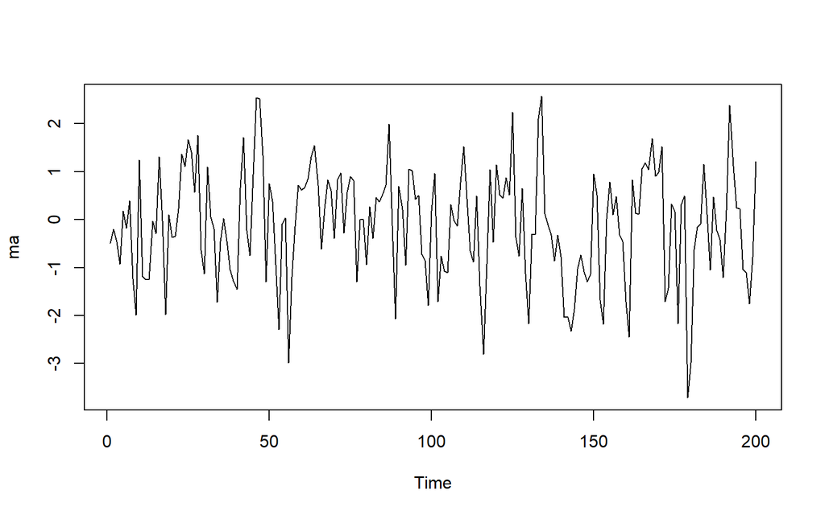

```r
ts.plot(ma)
```

Berdasarkan plot time series, terlihat bahwa data MA(1) yang dibangkitkan stasioner dalam rataan

### Plot ACF

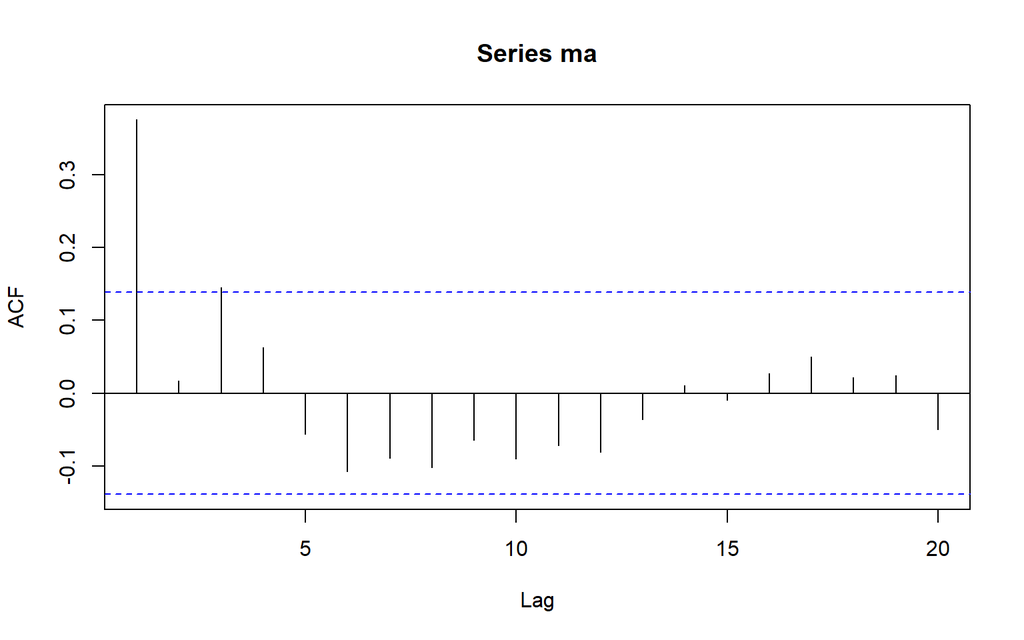

```r
acf(ma,lag.max = 20)
```

Berdasarkan plot AFC tersebut, terlihat bahwa plot ACF *cuts off* di lag pertama

### Plot PACF

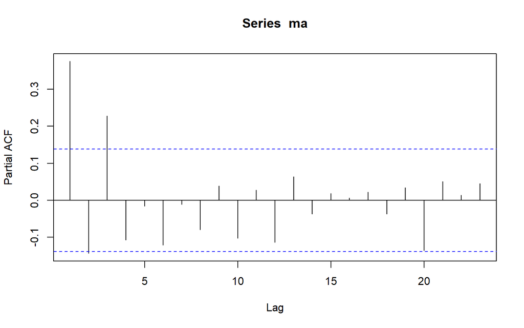

```r
pacf(ma)
```

Berdasarkan plot PACF tersebut, terlihat bahwa plot PACF cenderung *tails off* dan membentuk gelombang sinus

### Plot EACF

```r
TSA::eacf(ma)
```

```
## AR/MA
##   0 1 2 3 4 5 6 7 8 9 10 11 12 13
## 0 x o x o o o o o o o o  o  o  o
## 1 x o x o o o o o o o o  o  o  o
## 2 x x x o o o o o o o o  o  o  o
## 3 x x x x o o o o o o o  o  o  o
## 4 x x x o o o o o o o o  o  o  o
## 5 x x x o o o o o o o o  o  o  o
## 6 o x x o o o o o o o o  o  o  o
## 7 x x o x o o o o o o o  o  o  o
```

### Scatterplot Antar Lag

#### Korelasi antara $Y_t$ dengan $Y_{t-1}$

```r
#Yt
yt_ma <- ma[-1]
yt_ma
```

```
##   [1] -0.197160026 -0.456788931 -0.931629323  0.180381656 -0.180812561
##   [6]  0.396757822 -1.229652878 -1.985037549  1.241942041 -1.183445228
##  [11] -1.252621403 -1.249719968 -0.034234335 -0.288368817  1.309655437
##  [16] -0.022614750 -1.983772082  0.099558539 -0.368055551 -0.340285573
##  [21]  0.224565765  1.363834927  1.110757150  1.666265253  1.411178742
##  [26]  0.575372338  1.760131976 -0.636457358 -1.123802192  1.096555980
##  [31]  0.052812425 -0.183840872 -1.717377666 -0.451912690  0.020623628
##  [36] -0.442261802 -1.036189945 -1.268660896 -1.455381392  0.659392571
##  [41]  1.718539903 -0.225013773 -0.747246494  0.941884534  2.542921770
##  [46]  2.518131274  1.347119529 -1.296823215  0.746890529  0.388238525
##  [51] -0.937276032 -2.292858987 -0.087380873  0.041127553 -2.980989405
##  [56] -1.200198847 -0.147999864  0.722976379  0.614649282  0.672033591
##  [61]  0.851562851  1.315679167  1.544064687  0.714323435 -0.611479793
##  [66]  0.228265828  0.825923148  0.607482077 -0.384150365  0.827736222
##  [71]  0.977248356 -0.274909583  0.567501143  0.894856079  0.813724183
```

[output cut: 25 more lines]

```r
#Yt-1
yt_1_ma <- ma[-200]
yt_1_ma
```

```
##   [1] -0.486997705 -0.197160026 -0.456788931 -0.931629323  0.180381656
##   [6] -0.180812561  0.396757822 -1.229652878 -1.985037549  1.241942041
##  [11] -1.183445228 -1.252621403 -1.249719968 -0.034234335 -0.288368817
##  [16]  1.309655437 -0.022614750 -1.983772082  0.099558539 -0.368055551
##  [21] -0.340285573  0.224565765  1.363834927  1.110757150  1.666265253
##  [26]  1.411178742  0.575372338  1.760131976 -0.636457358 -1.123802192
##  [31]  1.096555980  0.052812425 -0.183840872 -1.717377666 -0.451912690
##  [36]  0.020623628 -0.442261802 -1.036189945 -1.268660896 -1.455381392
##  [41]  0.659392571  1.718539903 -0.225013773 -0.747246494  0.941884534
##  [46]  2.542921770  2.518131274  1.347119529 -1.296823215  0.746890529
##  [51]  0.388238525 -0.937276032 -2.292858987 -0.087380873  0.041127553
##  [56] -2.980989405 -1.200198847 -0.147999864  0.722976379  0.614649282
##  [61]  0.672033591  0.851562851  1.315679167  1.544064687  0.714323435
##  [66] -0.611479793  0.228265828  0.825923148  0.607482077 -0.384150365
##  [71]  0.827736222  0.977248356 -0.274909583  0.567501143  0.894856079
```

[output cut: 25 more lines]

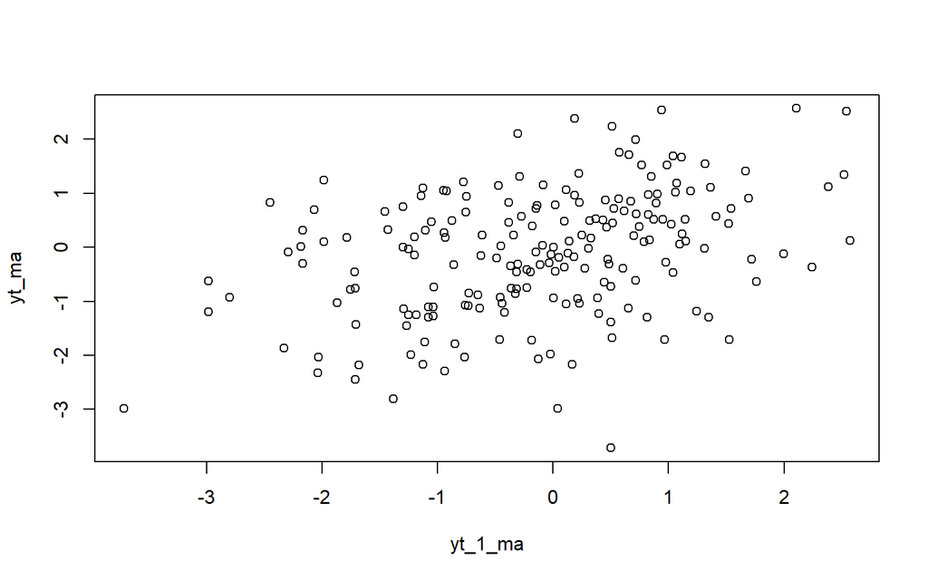

```r
plot(y=yt_ma,x=yt_1_ma)
```

Berdasarkan scatterplot tersebut, terlihat bahwa terdapat hubungan positif antara $Y_t$ dengan $Y_{t-1}$. Hal ini sesuai dengan teori yang ada

```r
cor(yt_ma,yt_1_ma)
```

```
## [1] 0.3768422
```

Korelasi antara $Y_t$ dengan $Y_{t-1}$ dari hasil simulasi mendekati perhitungan teoritis yaitu

$$\rho_1=\frac{-\theta}{1+(-\theta)^2}=\frac{-(-0.5)}{1+(-0.5)^2}=0.4$$

#### Korelasi antara $Y_t$ dengan $Y_{t-2}$

```r
#Yt
yt_ma2 <- ma[-c(1,2)]
yt_ma2
```

```
##   [1] -0.456788931 -0.931629323  0.180381656 -0.180812561  0.396757822
##   [6] -1.229652878 -1.985037549  1.241942041 -1.183445228 -1.252621403
##  [11] -1.249719968 -0.034234335 -0.288368817  1.309655437 -0.022614750
##  [16] -1.983772082  0.099558539 -0.368055551 -0.340285573  0.224565765
##  [21]  1.363834927  1.110757150  1.666265253  1.411178742  0.575372338
##  [26]  1.760131976 -0.636457358 -1.123802192  1.096555980  0.052812425
##  [31] -0.183840872 -1.717377666 -0.451912690  0.020623628 -0.442261802
##  [36] -1.036189945 -1.268660896 -1.455381392  0.659392571  1.718539903
##  [41] -0.225013773 -0.747246494  0.941884534  2.542921770  2.518131274
##  [46]  1.347119529 -1.296823215  0.746890529  0.388238525 -0.937276032
##  [51] -2.292858987 -0.087380873  0.041127553 -2.980989405 -1.200198847
##  [56] -0.147999864  0.722976379  0.614649282  0.672033591  0.851562851
##  [61]  1.315679167  1.544064687  0.714323435 -0.611479793  0.228265828
##  [66]  0.825923148  0.607482077 -0.384150365  0.827736222  0.977248356
##  [71] -0.274909583  0.567501143  0.894856079  0.813724183 -1.299386546
```

[output cut: 25 more lines]

```r
#Yt-2
yt_2_ma <- ma[-c(199,200)]
yt_2_ma
```

```
##   [1] -0.486997705 -0.197160026 -0.456788931 -0.931629323  0.180381656
##   [6] -0.180812561  0.396757822 -1.229652878 -1.985037549  1.241942041
##  [11] -1.183445228 -1.252621403 -1.249719968 -0.034234335 -0.288368817
##  [16]  1.309655437 -0.022614750 -1.983772082  0.099558539 -0.368055551
##  [21] -0.340285573  0.224565765  1.363834927  1.110757150  1.666265253
##  [26]  1.411178742  0.575372338  1.760131976 -0.636457358 -1.123802192
##  [31]  1.096555980  0.052812425 -0.183840872 -1.717377666 -0.451912690
##  [36]  0.020623628 -0.442261802 -1.036189945 -1.268660896 -1.455381392
##  [41]  0.659392571  1.718539903 -0.225013773 -0.747246494  0.941884534
##  [46]  2.542921770  2.518131274  1.347119529 -1.296823215  0.746890529
##  [51]  0.388238525 -0.937276032 -2.292858987 -0.087380873  0.041127553
##  [56] -2.980989405 -1.200198847 -0.147999864  0.722976379  0.614649282
##  [61]  0.672033591  0.851562851  1.315679167  1.544064687  0.714323435
##  [66] -0.611479793  0.228265828  0.825923148  0.607482077 -0.384150365
##  [71]  0.827736222  0.977248356 -0.274909583  0.567501143  0.894856079
```

[output cut: 25 more lines]

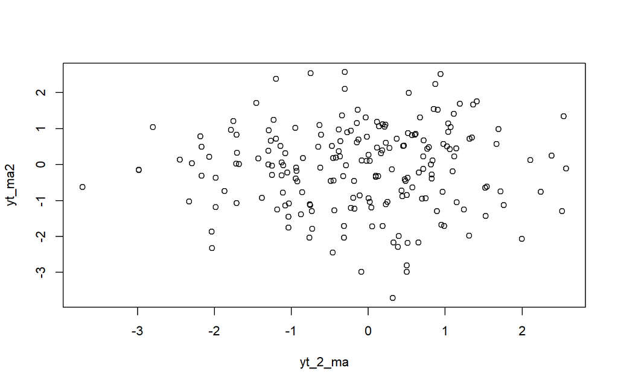

```r
plot(y=yt_ma2,x=yt_2_ma)
```

Berdasarkan scatterplot tersebut, terlihat bahwa cenderung tidak terdapat hubungan antara $Y_t$ dengan $Y_{t-2}$.

```r
cor(yt_ma2,yt_2_ma)
```

```
## [1] 0.01766615
```

Korelasi antara $Y_t$ dengan $Y_{t-2}$ hasil simulasi mendekati teori yang ada yaitu 0.

## Proses AR

Proses AR dapat dituliskan sebagai berikut:

$$y_{t} = c + e_t + \phi_{1}Y_{t-1} +
\phi_{2}Y_{t-2} + \dots + \phi_{q}Y_{t-q} = c+{e_t+\sum_{i=1}^p
\phi_iY_{t-i}}$$
Terlihat bahwa $Y_t$ berperan penting dalam pembangkitan proses AR.

## Pembangkitan Proses AR

Akan dicoba membangkitkan proses AR paling sederhana, yaitu AR(1) dengan $\phi = 0.7$ sebanyak 200 observasi dan $c=0$.

```r
set.seed(1234)
```

Nilai-nilai selanjutnya dapat dicari melalui *loop*. Bentuk loop dapat dilihat dari rumus AR(1) yang hendak dibangkitkan:

$$Y_t = e_t+0.7Y_{t-1}$$

```r
n<-length(wn)
n
```

```
## [1] 200
```

```r
ar <- c(1:n)
for (i in 2:n) {ar[i]<-wn[i]+0.7*ar[i-1]}
ar
```

```
##   [1]  1.000000000  0.746338827  0.042478835 -0.661914967  0.062866255
##   [6] -0.399909549  0.338779101 -1.301865399 -2.126837943  0.360921563
##  [11] -1.855654196 -1.497429695 -2.198684876 -0.998071703 -1.257522864
##  [16]  0.708825768 -0.320982599 -1.799879583 -0.372761288 -1.072565663
##  [21] -0.685265157 -0.287885248  1.066415072  1.223280327  2.284166593
##  [26]  2.296160176  1.834062681  2.930600574  0.591584695  0.020224947
##  [31]  1.307655613  0.321422279  0.338123048 -1.537255258 -0.641020674
##  [36] -0.645619847 -0.795743007 -1.421305493 -1.831432047 -2.319124724
##  [41] -0.445433590  0.817759531 -0.217363623 -0.504503382  0.764906589
##  [46]  2.519326904  3.289713961  2.886826737  0.431942019  1.843668291
##  [51]  0.908151890 -0.110361752 -1.997078176 -0.525423121 -0.762934433
##  [56] -3.317474384 -2.130720776 -1.735260054 -0.369827903 -0.066657317
##  [61]  0.529262362  0.934085262  1.687738046  2.208542138  1.746740179
##  [66]  0.510857992  0.941796489  1.193082742  1.175727397  0.268574074
##  [71]  1.292955625  1.329840406  0.443592967  1.121663879  1.274446393
```

[output cut: 25 more lines]

Selain menggunakan cara di atas, pembangkitan proses AR dapat dilakukan dengan fungsi `arima.sim()` sebagai berikut.

```r
ar1 <- arima.sim(list(order=c(1,0,0), ar=0.7), n=200)
ar1
```

```
## Time Series:
## Start = 1
## End = 200
## Frequency = 1
##   [1] -1.794742603  1.159515356  0.945748970  0.171338382 -0.320611005
##   [6]  0.235161738 -0.529107031 -1.818579832 -0.698250161 -1.512430836
##  [11] -1.073839886 -1.687636521 -0.079048019 -0.530926692 -1.081088722
##  [16] -1.258020166 -2.509707585 -2.924414572 -4.227129849 -4.299984087
##  [21] -3.304282719 -2.778895444 -0.495730545 -1.415654105 -1.846322508
##  [26] -1.573048757 -2.095474206 -2.435346262 -2.812060576 -3.220428289
##  [31] -2.778127921 -2.441539502 -3.515108908 -3.042652161 -3.238746137
##  [36] -3.282084305 -2.459768537 -1.158782157  0.836669963 -0.187684450
##  [41]  1.474530514 -0.125637188  0.568642433  2.947040774  2.028168152
##  [46]  0.750084127  0.517454133  2.139302341  0.358903902  1.619059911
##  [51]  2.462906728  2.060507507  1.449248093  0.559004927  0.024779516
```

[output cut: 29 more lines]

## Karakteristik AR(1)

### Plot Time Series

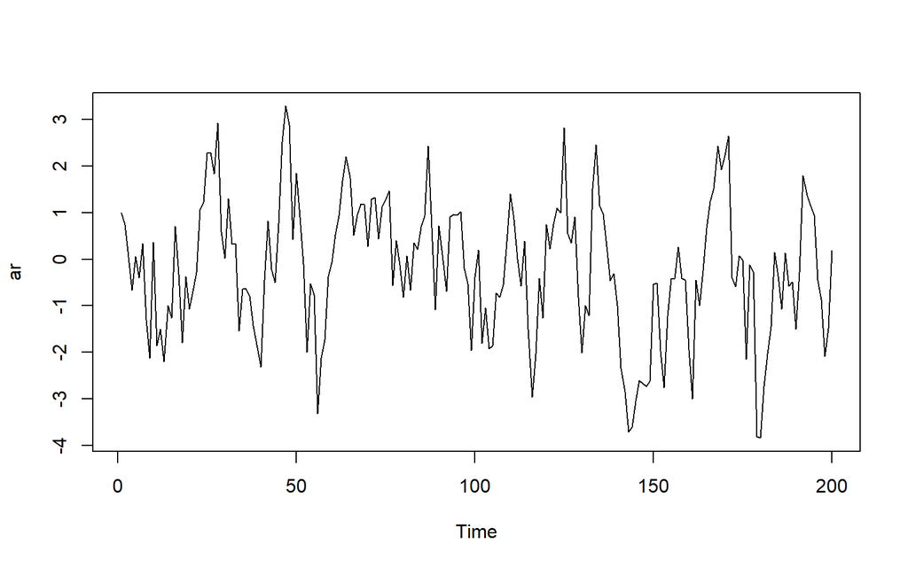

```r
ts.plot(ar)
```

Berdasarkan plot time series tersebut terlihat bahwa data cenderung stasioner pada rataan

### Plot ACF

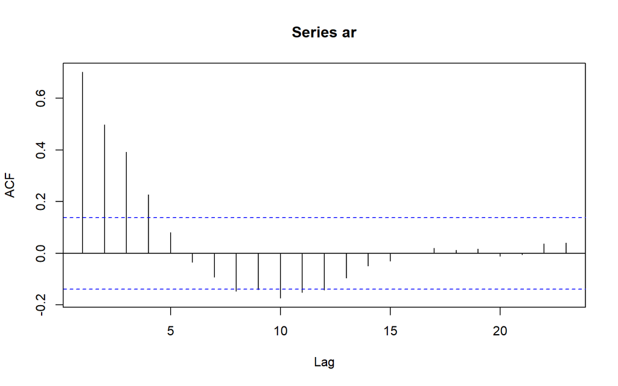

```r
acf(ar)
```

Berdasarkan plot ACF tersebut terlihat bahwa plot ACF cenderung *tails off* dan cenderung membentuk pola grafik sinus

### Plot PACF

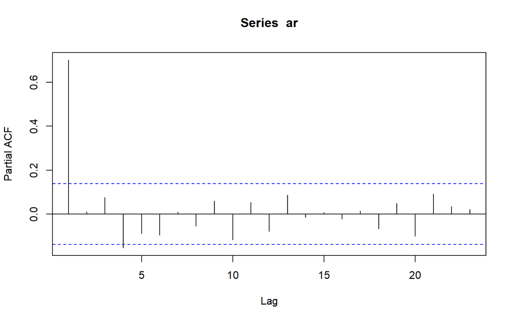

```r
pacf(ar)
```

Berdasarkan plot PACF tersebut, terlihat bahwa plot PACF *cuts off* pada lag pertama, sejalan dengan teori yang ada

### Plot EACF

```r
TSA::eacf(ar)
```

```
## AR/MA
##   0 1 2 3 4 5 6 7 8 9 10 11 12 13
## 0 x x x x o o o x o x x  o  o  o
## 1 o o x o o o o o o o o  o  o  o
## 2 o o x o o o o o o o o  o  o  o
## 3 x x x x o o o o o o o  o  o  o
## 4 x x x o o o o o o o o  o  o  o
## 5 x x o o o o o o o o o  o  o  o
## 6 x x o o o o o o o o o  o  o  o
## 7 x x o o o x o o o o o  o  o  o
```

Berdasarkan pola segitiga nol pada plot EACF, terlihat bahwa segitiga nol berada pada ordo AR(1) dan ordo MA(0)

### Scatterplot Antar Lag

#### Korelasi antara $Y_t$ dengan $Y_{t-1}$

```r
#Yt
yt_ar <- ar[-1]
yt_ar
```

```
##   [1]  0.746338827  0.042478835 -0.661914967  0.062866255 -0.399909549
##   [6]  0.338779101 -1.301865399 -2.126837943  0.360921563 -1.855654196
##  [11] -1.497429695 -2.198684876 -0.998071703 -1.257522864  0.708825768
##  [16] -0.320982599 -1.799879583 -0.372761288 -1.072565663 -0.685265157
##  [21] -0.287885248  1.066415072  1.223280327  2.284166593  2.296160176
##  [26]  1.834062681  2.930600574  0.591584695  0.020224947  1.307655613
##  [31]  0.321422279  0.338123048 -1.537255258 -0.641020674 -0.645619847
##  [36] -0.795743007 -1.421305493 -1.831432047 -2.319124724 -0.445433590
##  [41]  0.817759531 -0.217363623 -0.504503382  0.764906589  2.519326904
##  [46]  3.289713961  2.886826737  0.431942019  1.843668291  0.908151890
##  [51] -0.110361752 -1.997078176 -0.525423121 -0.762934433 -3.317474384
##  [56] -2.130720776 -1.735260054 -0.369827903 -0.066657317  0.529262362
##  [61]  0.934085262  1.687738046  2.208542138  1.746740179  0.510857992
##  [66]  0.941796489  1.193082742  1.175727397  0.268574074  1.292955625
##  [71]  1.329840406  0.443592967  1.121663879  1.274446393  1.461195819
```

[output cut: 25 more lines]

```r
#Yt-1
yt_1_ar <- ar[-200]
yt_1_ar
```

```
##   [1]  1.000000000  0.746338827  0.042478835 -0.661914967  0.062866255
##   [6] -0.399909549  0.338779101 -1.301865399 -2.126837943  0.360921563
##  [11] -1.855654196 -1.497429695 -2.198684876 -0.998071703 -1.257522864
##  [16]  0.708825768 -0.320982599 -1.799879583 -0.372761288 -1.072565663
##  [21] -0.685265157 -0.287885248  1.066415072  1.223280327  2.284166593
##  [26]  2.296160176  1.834062681  2.930600574  0.591584695  0.020224947
##  [31]  1.307655613  0.321422279  0.338123048 -1.537255258 -0.641020674
##  [36] -0.645619847 -0.795743007 -1.421305493 -1.831432047 -2.319124724
##  [41] -0.445433590  0.817759531 -0.217363623 -0.504503382  0.764906589
##  [46]  2.519326904  3.289713961  2.886826737  0.431942019  1.843668291
##  [51]  0.908151890 -0.110361752 -1.997078176 -0.525423121 -0.762934433
##  [56] -3.317474384 -2.130720776 -1.735260054 -0.369827903 -0.066657317
##  [61]  0.529262362  0.934085262  1.687738046  2.208542138  1.746740179
##  [66]  0.510857992  0.941796489  1.193082742  1.175727397  0.268574074
##  [71]  1.292955625  1.329840406  0.443592967  1.121663879  1.274446393
```

[output cut: 25 more lines]

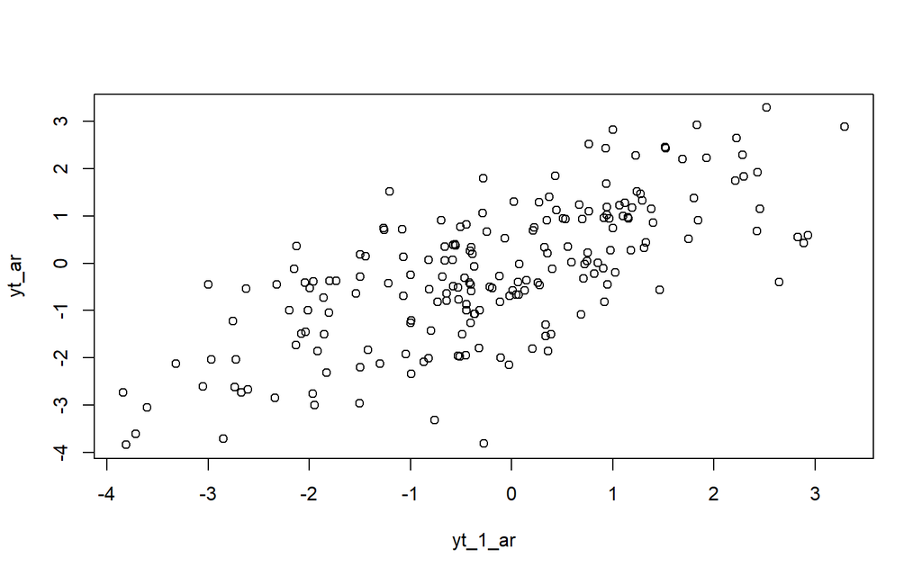

```r
plot(y=yt_ar,x=yt_1_ar)
```

Berdasarkan scatterplot tersebut, terlihat bahwa terdapat hubungan positif antara $Y_t$ dengan $Y_{t-1}$. Hal ini sesuai dengan teori yang ada

```r
cor(yt_ar,yt_1_ar)
```

```
## [1] 0.7024578
```

Korelasi antara $Y_t$ dengan $Y_{t-1}$ dari hasil simulasi mendekati perhitungan teoritis yaitu $\rho_1=\phi^1=0.7$

#### Korelasi antara $Y_t$ dengan $Y_{t-2}$

```r
#Yt
yt_ar2 <- ar[-c(1,2)]
yt_ar2
```

```
##   [1]  0.042478835 -0.661914967  0.062866255 -0.399909549  0.338779101
##   [6] -1.301865399 -2.126837943  0.360921563 -1.855654196 -1.497429695
##  [11] -2.198684876 -0.998071703 -1.257522864  0.708825768 -0.320982599
##  [16] -1.799879583 -0.372761288 -1.072565663 -0.685265157 -0.287885248
##  [21]  1.066415072  1.223280327  2.284166593  2.296160176  1.834062681
##  [26]  2.930600574  0.591584695  0.020224947  1.307655613  0.321422279
##  [31]  0.338123048 -1.537255258 -0.641020674 -0.645619847 -0.795743007
##  [36] -1.421305493 -1.831432047 -2.319124724 -0.445433590  0.817759531
##  [41] -0.217363623 -0.504503382  0.764906589  2.519326904  3.289713961
##  [46]  2.886826737  0.431942019  1.843668291  0.908151890 -0.110361752
##  [51] -1.997078176 -0.525423121 -0.762934433 -3.317474384 -2.130720776
##  [56] -1.735260054 -0.369827903 -0.066657317  0.529262362  0.934085262
##  [61]  1.687738046  2.208542138  1.746740179  0.510857992  0.941796489
##  [66]  1.193082742  1.175727397  0.268574074  1.292955625  1.329840406
##  [71]  0.443592967  1.121663879  1.274446393  1.461195819 -0.561091144
```

[output cut: 25 more lines]

```r
#Yt-2
yt_2_ar <- ar[-c(199,200)]
yt_2_ar
```

```
##   [1]  1.000000000  0.746338827  0.042478835 -0.661914967  0.062866255
##   [6] -0.399909549  0.338779101 -1.301865399 -2.126837943  0.360921563
##  [11] -1.855654196 -1.497429695 -2.198684876 -0.998071703 -1.257522864
##  [16]  0.708825768 -0.320982599 -1.799879583 -0.372761288 -1.072565663
##  [21] -0.685265157 -0.287885248  1.066415072  1.223280327  2.284166593
##  [26]  2.296160176  1.834062681  2.930600574  0.591584695  0.020224947
##  [31]  1.307655613  0.321422279  0.338123048 -1.537255258 -0.641020674
##  [36] -0.645619847 -0.795743007 -1.421305493 -1.831432047 -2.319124724
##  [41] -0.445433590  0.817759531 -0.217363623 -0.504503382  0.764906589
##  [46]  2.519326904  3.289713961  2.886826737  0.431942019  1.843668291
##  [51]  0.908151890 -0.110361752 -1.997078176 -0.525423121 -0.762934433
##  [56] -3.317474384 -2.130720776 -1.735260054 -0.369827903 -0.066657317
##  [61]  0.529262362  0.934085262  1.687738046  2.208542138  1.746740179
##  [66]  0.510857992  0.941796489  1.193082742  1.175727397  0.268574074
##  [71]  1.292955625  1.329840406  0.443592967  1.121663879  1.274446393
```

[output cut: 25 more lines]

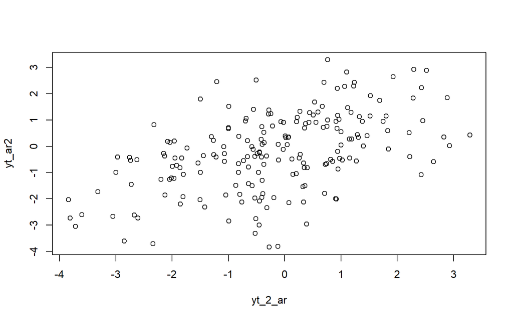

```r
plot(y=yt_ar2,x=yt_2_ar)
```

Berdasarkan scatterplot tersebut, terlihat bahwa terdapat hubungan positif antara $Y_t$ dengan $Y_{t-2}$. Hal ini sesuai dengan teori yang ada

```r
cor(yt_ar2,yt_2_ar)
```

```
## [1] 0.5001033
```

Korelasi antara $Y_t$ dengan $Y_{t-2}$ dari hasil simulasi mendekati perhitungan teoritis yaitu $\rho_2=\phi^2=0.49$.

## Fungsi pembangkitan ARMA

Setelah mengetahui cara membangkitkan data berpola AR, MA, dan ARMA sederhana, bagaimana cara melakukan pembangkitan data berpola tersebut yang lebih kompleks? Apakah dapat dibuat suatu fungsi yang fleksibel yang memungkinan pembangkitan dengan berapapun jumlah koefisien?

Pertama, lihat kembali bentuk umum data berpola ARMA.

$$y_{t} = c + \sum_{i=1}^p \phi_{i}y_{t-i} + \sum_{j=1}^q e_{t-j}+ e_{t}$$

Komponen $c$ dan $e_{t}$ cukup mudah untuk dibuat dan dicari. Bagaimana untuk komponen AR dan MA? Bayangkan ada koefisien dan data sebagai berikut:

$$\begin{aligned}
\begin{bmatrix}
\phi_1 \ \phi_2 \ \phi_3
\end{bmatrix}&=
\begin{bmatrix}
0.3 \ 0.5 \ 0.2
\end{bmatrix}
\\
\begin{bmatrix}
y_{t-1} \ y_{t-2} \ y_{t-3}
\end{bmatrix}&=
\begin{bmatrix}
1 \ 2 \ 3
\end{bmatrix}
\end{aligned}$$

Maka dari itu,

$$\begin{aligned}
\begin{bmatrix}
\phi_1 \ \phi_2 \ \phi_3
\end{bmatrix}
\begin{bmatrix}
y_{t-1} \\ y_{t-2} \\ y_{t-3}
\end{bmatrix} &= \phi_1 \ y_{t-1}+\phi_2 \ y_{t-2}+\phi_3 \ y_{t-3}
\\
\begin{bmatrix}
0.3 \ 0.5 \ 0.2
\end{bmatrix}
\begin{bmatrix}
1 \\ 2 \\ 3
\end{bmatrix} & = 0.3 \cdot1+0.5 \cdot 2+0.2 \cdot 3\\
&=0.3+1+0.6 = 1.9
\end{aligned}$$

Jika koefisien dan *white noise*/nilai deret waktu sebelumnya dapat diekstrak dalam bentuk vektor, dapat dilakukan perkalian matriks untuk mencari nilai bagian AR dan MA:

```r
set.seed(30)
coefs <- c(0.3, 0.5, 0.2)
e <- c(1, 2, 3)

coefs %*% e
```

```
##      [,1]
## [1,]  1.9
```

Atau, dapat dilakukan perkalian *elementwise* yang dijumlahkan:

```r
coefs * e
```

```
## [1] 0.3 1.0 0.6
```

```r
sum(coefs * e)
```

```
## [1] 1.9
```

Dari prinsip ini, dapat dibuat fungsi umum untuk membangkitkan data ARMA. Input dari fungsi adalah jumlah data yang hendak dibangkitkan, koefisien MA, dan koefisien AR

```r
arma.sim <- function(n, macoef, arcoef){
  manum <- length(macoef)
  arnum <- length(arcoef)
  stopifnot(manum < n & arnum < n)

  wn <- rnorm(n, sd = 0.5)
  init <- max(manum, arnum)

  arma <- wn[1:init]
  for(i in {init+1}:n){
   mastart <- i - manum
   maend <- i-1
   arstart <- i - arnum
   arend <- i-1
   arma[i] <- sum(arcoef * arma[arstart:arend]) + sum(macoef * wn[mastart:maend])  + wn[i]
   }
  return(arma)
}
```

Terlihat bahwa komponen $\sum_{i=1}^q y_{t-1}$ disimulasikan melalui `sum(arcoef * arma[arstart:arend])`. Jadi, koefisien dikalikan dengan data $y$ dari $t-q$ di mana q adalah jumlah koefisien AR, sampai data $t-1$. Lalu komponen $\sum_{j=1}^q e_{t-j}$ disimulasikan melalui `sum(macoef * wn[mastart:maend])`. Koefisien dikalikan dengan *white noise* $e$ dari $t-p$, p jumlah koefisien MA, sampai $t-1$.

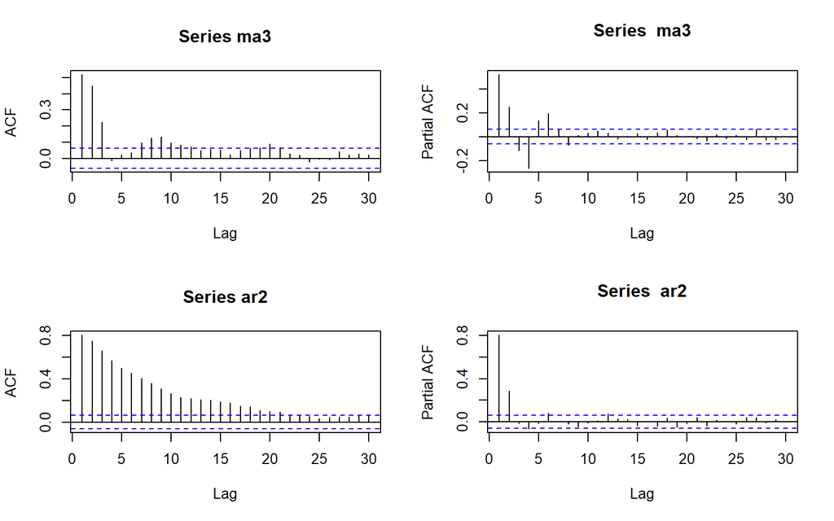

```r
# beberapa contoh pembangkitan melalui fungsi

ma3 <- arma.sim(1000, c(0.4, 0.6,0.4), 0)
ar2 <- arma.sim(1000, 0, c(0.3, 0.6))

par(mfrow = c(2, 2))
acf(ma3)
pacf(ma3)
acf(ar2)
pacf(ar2)
```

```r
#contoh untuk ARMA
arma22 <- arma.sim(2000, c(0.3, 0.4), c(0.3,0.4))

arma22 |> arima(c(2,0,2))
```

```
##
## Call:
## arima(x = arma22, order = c(2, 0, 2))
##
## Coefficients:
##          ar1     ar2     ma1     ma2  intercept
##       0.4216  0.2848  0.3898  0.3052    -0.0186
## s.e.  0.0678  0.0619  0.0658  0.0260     0.0630
##
## sigma^2 estimated as 0.2392:  log likelihood = -1408.11,  aic = 2826.23
```

```r
set.seed(1234)
n = length(wn)
phi1 = 0.7
theta1 = 0.5

y.arma=c(1:n)
for (i in 2:n){y.arma[i] = phi1*y.arma[i-1] + theta1*wn[i-1]+wn[i]}
y.arma
```

```
##   [1]  1.000000000  0.502839974 -0.104800949 -1.004989988 -0.523111335
##   [6] -0.546990496  0.013864475 -1.219947745 -2.839000970 -0.745358638
##  [11] -1.705196275 -2.446258795 -2.962101125 -2.107705122 -1.763762403
##  [16]  0.075021755  0.029900478 -1.962841747 -1.274430684 -1.260157030
##  [21] -1.222395494 -0.631111081  0.922057170  1.756197169  2.895603271
##  [26]  3.438101032  2.982043060  3.847562118  2.056836125  0.315983095
##  [31]  1.317744146  0.975233328  0.498822458 -1.368201945 -1.409654051
##  [36] -0.966134208 -1.118555747 -1.819178968 -2.542086174 -3.234841713
##  [41] -1.604996628  0.595042263  0.191515811 -0.613185426  0.512654736
##  [46]  2.901780085  4.549377334  4.531683662  1.875355348  2.059639273
##  [51]  1.829986017  0.343714179 -2.052259061 -1.523962216 -1.025645998
##  [56] -3.698941604 -3.789457970 -2.800620443 -1.237457931 -0.251571270
##  [61]  0.495933702  1.198716443  2.154780677  3.052411161  2.851011248
##  [66]  1.384228081  1.197225485  1.663980987  1.772268768  0.856437772
##  [71]  1.427242662  1.976318219  1.108513170  1.343460362  1.835278333
```

[output cut: 25 more lines]

Pembangkitan ARMA(p,q) juga dapat dilakukan dengan fungsi `arima.sim` sebagai berikut.

```r
arma11 <- arima.sim(list(order=c(1,0,1), ar = 0.7, ma = 0.5), n=200)
arma11
```

```
## Time Series:
## Start = 1
## End = 200
## Frequency = 1
##   [1]  0.26351998  1.52646979  0.64488707 -0.23446987  0.07518659 -0.41129491
##   [7] -2.08297147 -1.60742676 -1.86147660 -1.82999978 -2.22451760 -0.92283907
##  [13] -0.57043166 -1.34653874 -1.79855519 -3.13871114 -4.17926379 -5.68933393
##  [19] -6.41354677 -5.45427319 -4.43103571 -1.88517750 -1.66351884 -2.55414918
##  [25] -2.49620975 -2.88199840 -3.48308324 -4.02973362 -4.62645851 -4.38834202
##  [31] -3.83060343 -4.73587864 -4.80020660 -4.76007221 -4.90145737 -4.10081068
##  [37] -2.38866642  0.25727889  0.23065053  1.38068829  0.61162807  0.50582384
##  [43]  3.23136199  3.50168854  1.76416820  0.89249620  2.39802941  1.42855507
##  [49]  1.79851186  3.27243668  3.29196087  2.47950185  1.28362897  0.30428198
##  [55]  0.67802199  2.86902954  2.89005769  0.55564023 -1.02998409 -0.82451799
##  [61] -0.76509083 -0.87188309 -0.86920722 -2.06574398 -2.30595890 -0.85083256
```

[output cut: 23 more lines]

## Karakteristik ARMA(1,1)

### Plot Time Series

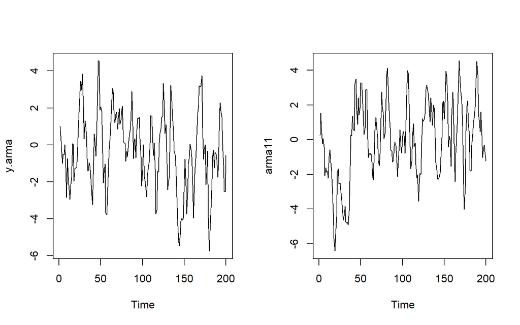

```r
par(mfrow = c(1, 2))
ts.plot(y.arma)
ts.plot(arma11)
```

```r
par(mfrow = c(1, 1))
```

Berdasarkan plot time series tersebut, terlihat bahwa model ARMA(1,1) cenderung stasioner dalam rataan

### Plot ACF

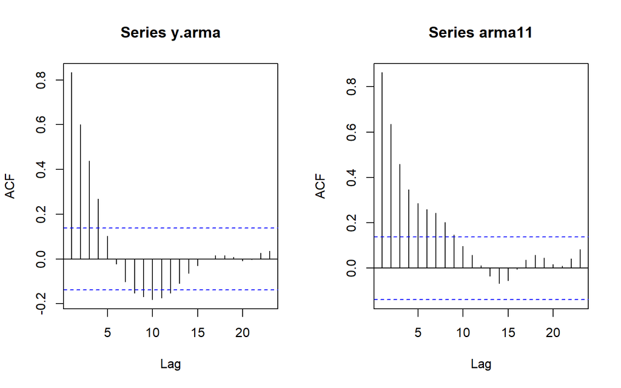

```r
par(mfrow = c(1, 2))
acf(y.arma)
acf(arma11)
```

```r
par(mfrow = c(1, 1))
```

Berdasarkan plot ACF tersebut, terlihat bahwa model ARMA(1,1) hasil simulasi memiliki plot ACF yang *tails off*, sesuai dengan teori yang ada

### Plot PACF

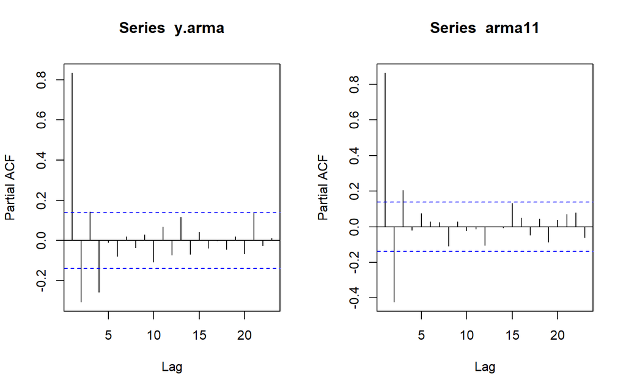

```r
par(mfrow = c(1, 2))
pacf(y.arma)
pacf(arma11)
```

```r
par(mfrow = c(1, 1))
```

Berdasarkan plot PACF tersebut, terlihat bahwa model ARMA(1,1) hasil simulasi memiliki plot PACF yang *tails off*, sesuai dengan teori

### Plot EACF

```r
TSA::eacf(y.arma)
```

```
## AR/MA
##   0 1 2 3 4 5 6 7 8 9 10 11 12 13
## 0 x x x x o o o x x x x  x  o  o
## 1 x o x x o o o o o o o  o  o  o
## 2 x o x o o o o o o o o  o  o  o
## 3 x x x x o o o o o o o  o  o  o
## 4 o x x x x o o o o o o  o  o  o
## 5 o x o o o o o o o o o  o  o  o
## 6 x x o o o o o o o o o  o  o  o
## 7 x x o o o o o o o o o  o  o  o
```

```r
TSA::eacf(arma11)
```

```
## AR/MA
##   0 1 2 3 4 5 6 7 8 9 10 11 12 13
## 0 x x x x x x x x x o o  o  o  o
## 1 x o o o o o o o o o o  o  o  x
## 2 x x o o o o o o o o o  o  o  o
## 3 o x o o o o o o o o o  o  o  o
## 4 x x o o o o o o o o o  o  o  o
## 5 x x o o x o o o o o o  o  o  o
## 6 x o x o x o o o o o o  o  o  o
## 7 x x x x x o o o o o o  o  o  o
```

### Scatterplot Antar Lag

#### Korelasi antara $Y_t$ dengan $Y_{t-1}$

```r
#Yt
yt_arma <- arma11[-1]
yt_arma
```

```
##   [1]  1.52646979  0.64488707 -0.23446987  0.07518659 -0.41129491 -2.08297147
##   [7] -1.60742676 -1.86147660 -1.82999978 -2.22451760 -0.92283907 -0.57043166
##  [13] -1.34653874 -1.79855519 -3.13871114 -4.17926379 -5.68933393 -6.41354677
##  [19] -5.45427319 -4.43103571 -1.88517750 -1.66351884 -2.55414918 -2.49620975
##  [25] -2.88199840 -3.48308324 -4.02973362 -4.62645851 -4.38834202 -3.83060343
##  [31] -4.73587864 -4.80020660 -4.76007221 -4.90145737 -4.10081068 -2.38866642
##  [37]  0.25727889  0.23065053  1.38068829  0.61162807  0.50582384  3.23136199
##  [43]  3.50168854  1.76416820  0.89249620  2.39802941  1.42855507  1.79851186
##  [49]  3.27243668  3.29196087  2.47950185  1.28362897  0.30428198  0.67802199
##  [55]  2.86902954  2.89005769  0.55564023 -1.02998409 -0.82451799 -0.76509083
##  [61] -0.87188309 -0.86920722 -2.06574398 -2.30595890 -0.85083256  0.52714205
##  [67]  1.26780114  0.75972750  0.13884949 -1.19313012 -1.48561384 -0.81131310
##  [73]  1.26564284  2.74044524  1.92348485  1.45419797  0.06110569  0.35367359
##  [79]  1.65959008  3.76928854  4.11358406  2.61205214  1.65707075  0.69046849
##  [85] -0.59390953 -0.66174669 -1.27599267 -1.17314179 -0.38213830 -0.14211780
```

[output cut: 19 more lines]

```r
#Yt-1
yt_1_arma <- arma11[-200]
yt_1_arma
```

```
##   [1]  0.26351998  1.52646979  0.64488707 -0.23446987  0.07518659 -0.41129491
##   [7] -2.08297147 -1.60742676 -1.86147660 -1.82999978 -2.22451760 -0.92283907
##  [13] -0.57043166 -1.34653874 -1.79855519 -3.13871114 -4.17926379 -5.68933393
##  [19] -6.41354677 -5.45427319 -4.43103571 -1.88517750 -1.66351884 -2.55414918
##  [25] -2.49620975 -2.88199840 -3.48308324 -4.02973362 -4.62645851 -4.38834202
##  [31] -3.83060343 -4.73587864 -4.80020660 -4.76007221 -4.90145737 -4.10081068
##  [37] -2.38866642  0.25727889  0.23065053  1.38068829  0.61162807  0.50582384
##  [43]  3.23136199  3.50168854  1.76416820  0.89249620  2.39802941  1.42855507
##  [49]  1.79851186  3.27243668  3.29196087  2.47950185  1.28362897  0.30428198
##  [55]  0.67802199  2.86902954  2.89005769  0.55564023 -1.02998409 -0.82451799
##  [61] -0.76509083 -0.87188309 -0.86920722 -2.06574398 -2.30595890 -0.85083256
##  [67]  0.52714205  1.26780114  0.75972750  0.13884949 -1.19313012 -1.48561384
##  [73] -0.81131310  1.26564284  2.74044524  1.92348485  1.45419797  0.06110569
##  [79]  0.35367359  1.65959008  3.76928854  4.11358406  2.61205214  1.65707075
##  [85]  0.69046849 -0.59390953 -0.66174669 -1.27599267 -1.17314179 -0.38213830
```

[output cut: 19 more lines]

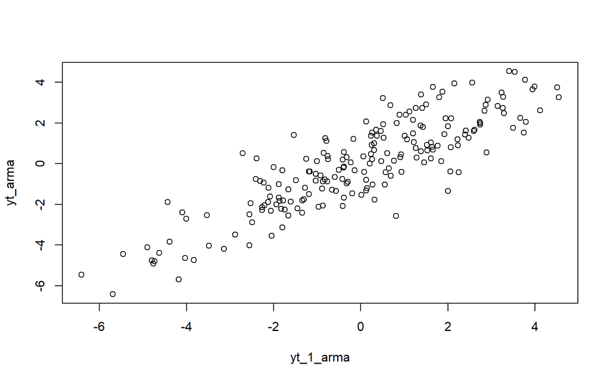

```r
plot(y=yt_arma,x=yt_1_arma)
```

Berdasarkan scatterplot tersebut, terlihat bahwa terdapat hubungan positif antara $Y_t$ dengan $Y_{t-1}$. Hal ini sesuai dengan teori yang ada

```r
cor(yt_arma,yt_1_arma)
```

```
## [1] 0.8628383
```

Korelasi antara $Y_t$ dengan $Y_{t-1}$ dari hasil simulasi mendekati perhitungan teoritis.
$$\rho_k = \frac{(1-\theta
\phi)(\phi-\theta)}{1-2\theta\phi+\theta^2}\phi^{k-1} \:untuk \:k\ge1$$

$$\rho_1 =
\frac{(1-((-0.5)(0.7)))(0.7-(-0.5))}{1-2(-0.5)(0.7)+(-0.5)^2}0.7^{1-1}=0,8307692$$